# Modelação Bayesiana

Diogo Freitas

João Francisco Botas

Miguel Gonçalves

Ricardo Galvão

19-03-2025

# Modelação Bayesiana

## Artigo de referência

O artigo de referência para este trabalho é o [Data on higher education student ethics model](https://www.sciencedirect.com/science/article/pii/S2352340919312594?via%3Dihub). Este artigo analisa dados de um questionário aplicado a estudantes de ensino superior para avaliar a ética dos mesmos. O questionário foi aplicado a 566 estudantes entre o período de Janeiro a Dezembro de 2018, na cidade de Yogyakarta, na Indonesia. Para percebermos melhor o conjunto de dados e a sua estrutura, vamos carregar o ficheiro de dados e fazer uma pequena analise exploratória de dados, complementando a informação com a descrição do artigo.

## Fase 1 - EDA

```r
# load data
df <- read.csv("../data/dados_raw.csv")
# View(df)
# df %>% glimpse()
```

Skim do dataset para vermos a estrutura detalhada dos dados.

```r
df %>% skimr::skim() -> skim_output
###########
# skim_output
# str(skim_output) # ver a estrutura para filtrar
###########
min(skim_output$complete_rate) # todas as colunas têm valores preenchidos
max(colSums(is.na(df)))
```

```
## [1] 1
## [1] 0
```

Ao guardarmos o skim num objeto podemos ver a estrutura e filtrar as informações que queremos. Neste caso, conseguimos ver que todas as colunas: - têm todos os valores preenchidos $\rightarrow$ mínimo do `complete_rate` é 1; - não existem valores em falta, consequentemente $\rightarrow$ máximo do número de valores em falta é 0.

Ou seja, não teremos de lidar com omissos.

```r
# select character columns
skim_output$skim_variable[skim_output$skim_type == "character"] -> char_cols
char_cols
# select numeric columns
skim_output$skim_variable[skim_output$skim_type == "numeric"] -> num_cols
length(num_cols) # = 127 total - 1 (Fak)
```

```
## [1] "Fak"
## [1] 126
```

### Variáveis categóricas

No dataset só temos uma variável categórica, a `Fak`. Vamos fazer uma tabela de frequências para esta variável e um gráfico de barras. Esta variável, segundo o artigo, é a *faculty*/departamento a que o estudante pertence (**Table 8** artigo).

| Departamento | Nº alunos | Percentagem |
| --- | --- | --- |
| Economic | 114 | 20.1% |
| Engineering | 98 | 17.3% |
| Mathematics and Natural Science | 85 | 15.0% |
| Social Science | 61 | 10.8% |
| Sports Science | 15 | 2.7% |
| Art | 120 | 21.2% |
| Educational Science | 73 | 12.9% |

```r
# fazer uma tabela de frequências para as variáveis categóricas
df %>% select(all_of(char_cols)) %>% map(table)
```

```
## $Fak
##
##  FBS   FE  FIK  FIP  FIS   FT MIPA
##  120  114   15   73   61   98   85
```

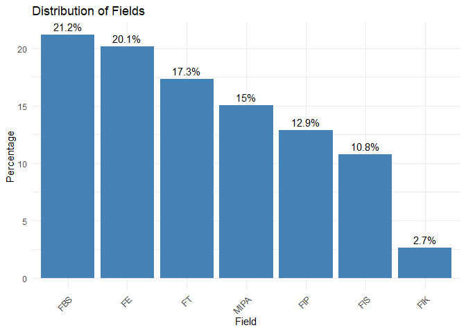

```r
# gráfico de barras
df %>%
  group_by(Fak) %>%
  summarise(Count = n()) %>%
  mutate(Percentage = Count / sum(Count) * 100) %>%
  ggplot(aes(x = reorder(Fak, -Percentage), y = Percentage)) +
  geom_bar(stat = "identity", fill = "steelblue") +
  geom_text(aes(label = paste0(round(Percentage, 1), "%")), vjust = -0.5) +
  labs(x = "Field", y = "Percentage", title = "Distribution of Fields") +
  theme_minimal() +
  theme(axis.text.x = element_text(angle = 45, hjust = 1))
```

Conseguimos perceber que há uma relação com os resultados mencionados no artigo.

| Departamento | Sigla |
| --- | --- |
| Economic | FE |
| Engineering | FT |
| Mathematics and Natural Science | MIPA |
| Social Science | FIS |
| Sports Science | FIK |
| Art | FBS |
| Educational Science | FIP |

A partir de agora vamos guardar os dados num novo dataset para podermos fazer a modelação.

```r
df_transform <- df
df_transform <- df_transform %>%
  mutate(Fak = case_when(
    Fak == "FE" ~ "Economic",
    Fak == "FT" ~ "Engineering",
    Fak == "MIPA" ~ "Mathematics and Natural Science",
    Fak == "FIS" ~ "Social Science",
    Fak == "FIK" ~ "Sports Science",
    Fak == "FBS" ~ "Art",
    Fak == "FIP" ~ "Educational Science",
    TRUE ~ Fak
  ))
summary(as.factor(df_transform$Fak)) # factor para mostrar a coluna alterada
```

```
##                             Art                        Economic
##                             120                             114
##             Educational Science                     Engineering
##                              73                              98
## Mathematics and Natural Science                  Social Science
##                              85                              61
##                  Sports Science
##                              15
```

### Variáveis numéricas citadas no artigo

O artigo menciona que o questionário tem 7 grupos de perguntas que medem dimensões diferentes. Cada grupo está associado a um nome que, por sua vez, tem uma sigla associada.

1. **Ethical behaviour** (ET)
2. **Motivation** (Mot)
3. **Self-efficacy** (SE)
4. **Resilience** (R)
5. **Knowledge articulation** (KA)
6. **Team strain** (TS)
7. **Cooperative classroom environment** (CCE)

Vamos selecionar as variáveis que pertencem a cada grupo e guardá-las em objetos diferentes. No final vamos juntar estas variáveis num novo dataset.

```r
# select das variáveis numéricas mencionadas no artigo -> regex para ser + facil :)
ethical_behaviour <- df_transform %>%
  select(matches("^ET[1-9]$|^ET1[0-4]$"))
#ethical_behaviour

motivation <- df_transform %>%
  select(matches("^Mot[1-9]$|^Mot1[0-5]$"))
#motivation

self_efficacy <- df_transform %>%
  select(matches("^SE[1-6]$"))
#self_efficacy

resilience <- df_transform %>%
  select(matches("^R[1-6]$"))
#resilience

knowledge_articulation <- df_transform %>%
  select(matches("^KA[1-5]$"))
#knowledge_articulation

team_strain <- df_transform %>%
  select(matches("^TS[1-9]$|^TS1[0-7]$"))
#team_strain

cooperative_classroom_environment <- df_transform %>%
  select(matches("^CCE[1-9]$|^CCE1[0-9]$|^CCE20$"))
#cooperative_classroom_environment

## falta 3xPOP; 6xPC; 6xOPT; 5xINO; 3xPDC

# juntar todos os dataframes com as colunas mencionadas no artigo (as acima)
vars_artigo <- bind_cols(ethical_behaviour, motivation, self_efficacy,
                         resilience, knowledge_articulation, team_strain,
                         cooperative_classroom_environment)
vars_artigo
```

| ET1 | ET2 | ET3 | ET4 | ET5 | ET6 | ET7 | ET8 | ET9 | ET10 | ET11 | ET12 | ET13 | ET14 | Mot1 | Mot2 | Mot3 | Mot4 | Mot5 | Mot6 | Mot7 | Mot8 | Mot9 | Mot10 | Mot11 | Mot12 | Mot13 | Mot14 | Mot15 | SE1 | … |
| --- | --- | --- | --- | --- | --- | --- | --- | --- | --- | --- | --- | --- | --- | --- | --- | --- | --- | --- | --- | --- | --- | --- | --- | --- | --- | --- | --- | --- | --- | --- |
| 1 | 4 | 4 | 3 | 1 | 1 | 3 | 3 | 4 | 4 | 4 | 3 | 4 | 4 | 3 | 4 | 4 | 4 | 2 | 4 | 4 | 2 | 4 | 4 | 2 | 4 | 4 | 4 | 2 | 3 | … |
| 1 | 2 | 1 | 2 | 2 | 2 | 5 | 5 | 5 | 5 | 5 | 5 | 5 | 4 | 4 | 4 | 4 | 5 | 3 | 5 | 4 | 3 | 4 | 4 | 3 | 4 | 5 | 5 | 1 | 4 | … |
| 1 | 1 | 1 | 5 | 1 | 1 | 5 | 5 | 5 | 1 | 1 | 1 | 1 | 1 | 4 | 5 | 2 | 2 | 2 | 5 | 5 | 1 | 1 | 5 | 1 | 4 | 5 | 5 | 1 | 5 | … |
| 1 | 4 | 1 | 1 | 1 | 3 | 4 | 4 | 5 | 5 | 4 | 2 | 2 | 2 | 4 | 4 | 4 | 3 | 2 | 4 | 2 | 4 | 3 | 3 | 3 | 4 | 5 | 3 | 1 | 3 | … |
| 3 | 3 | 2 | 3 | 3 | 3 | 4 | 4 | 5 | 4 | 4 | 4 | 4 | 3 | 4 | 3 | 2 | 4 | 2 | 4 | 4 | 2 | 4 | 3 | 3 | 4 | 4 | 4 | 3 | 4 | … |
| 2 | 3 | 1 | 2 | 2 | 2 | 4 | 4 | 4 | 2 | 3 | 3 | 4 | 5 | 4 | 4 | 3 | 3 | 3 | 4 | 4 | 1 | 4 | 3 | 3 | 4 | 5 | 4 | 1 | 4 | … |
| 1 | 2 | 1 | 2 | 2 | 2 | 5 | 5 | 5 | 5 | 5 | 5 | 5 | 4 | 4 | 4 | 4 | 5 | 3 | 5 | 4 | 3 | 4 | 4 | 3 | 4 | 5 | 5 | 1 | 4 | … |
| 4 | 4 | 3 | 4 | 4 | 3 | 4 | 4 | 4 | 5 | 3 | 4 | 3 | 4 | 4 | 4 | 4 | 4 | 4 | 4 | 4 | 4 | 4 | 4 | 4 | 4 | 4 | 4 | 5 | 4 | … |
| 1 | 4 | 4 | 4 | 1 | 1 | 4 | 4 | 4 | 4 | 3 | 3 | 3 | 4 | 5 | 5 | 3 | 4 | 2 | 4 | 3 | 2 | 4 | 4 | 4 | 5 | 5 | 4 | 1 | 4 | … |
| 2 | 5 | 2 | 3 | 3 | 3 | 5 | 5 | 4 | 5 | 4 | 4 | 4 | 5 | 4 | 4 | 4 | 4 | 3 | 5 | 4 | 4 | 5 | 5 | 3 | 5 | 5 | 5 | 3 | 4 | … |

[output cut: 556 more lines]

| ET1 <int> | ET2 <int> | ET3 <int> | ET4 <int> | ET5 <int> | ET6 <int> | ET7 <int> | ET8 <int> | ET9 <int> | ET10 <int> |  |
| --- | --- | --- | --- | --- | --- | --- | --- | --- | --- | --- |
| 1 | 4 | 4 | 3 | 1 | 1 | 3 | 3 | 4 | 4 |  |
| 1 | 2 | 1 | 2 | 2 | 2 | 5 | 5 | 5 | 5 |  |
| 1 | 1 | 1 | 5 | 1 | 1 | 5 | 5 | 5 | 1 |  |
| 1 | 4 | 1 | 1 | 1 | 3 | 4 | 4 | 5 | 5 |  |
| 3 | 3 | 2 | 3 | 3 | 3 | 4 | 4 | 5 | 4 |  |
| 2 | 3 | 1 | 2 | 2 | 2 | 4 | 4 | 4 | 2 |  |
| 1 | 2 | 1 | 2 | 2 | 2 | 5 | 5 | 5 | 5 |  |
| 4 | 4 | 3 | 4 | 4 | 3 | 4 | 4 | 4 | 5 |  |
| 1 | 4 | 4 | 4 | 1 | 1 | 4 | 4 | 4 | 4 |  |
| 2 | 5 | 2 | 3 | 3 | 3 | 5 | 5 | 4 | 5 |  |

...

1-10 of 566 rows | 1-10 of 83 columns

#### Correlação entre variáveis

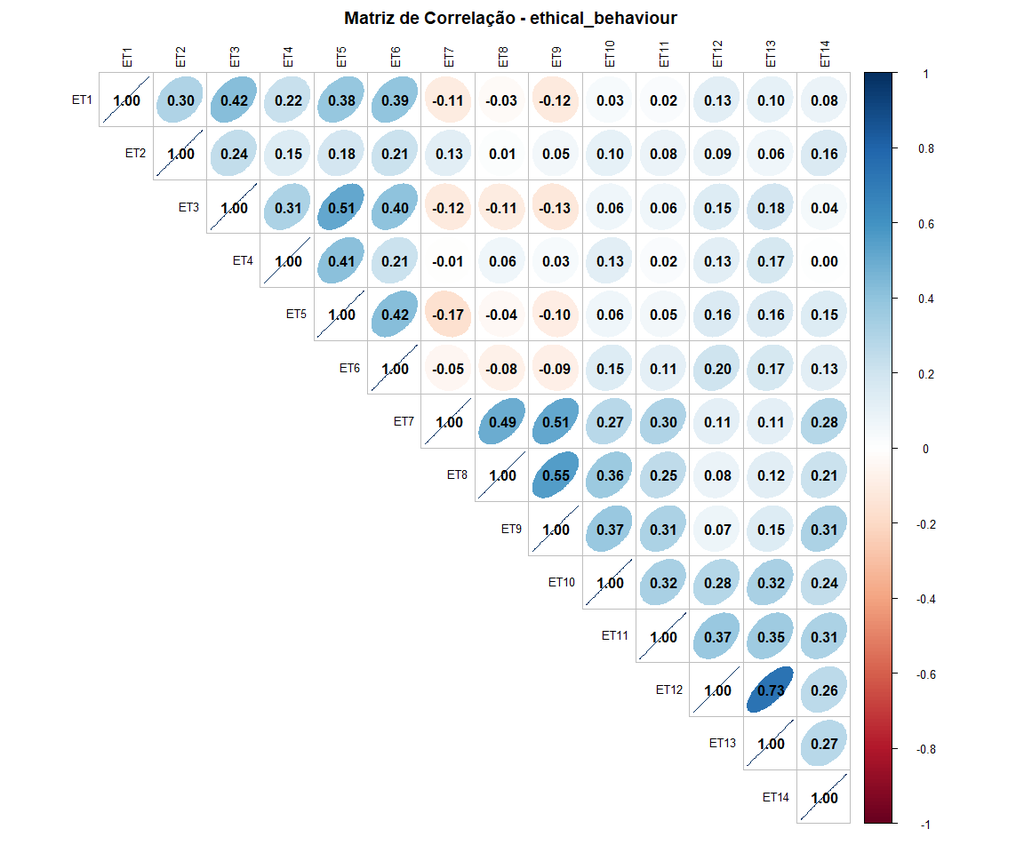

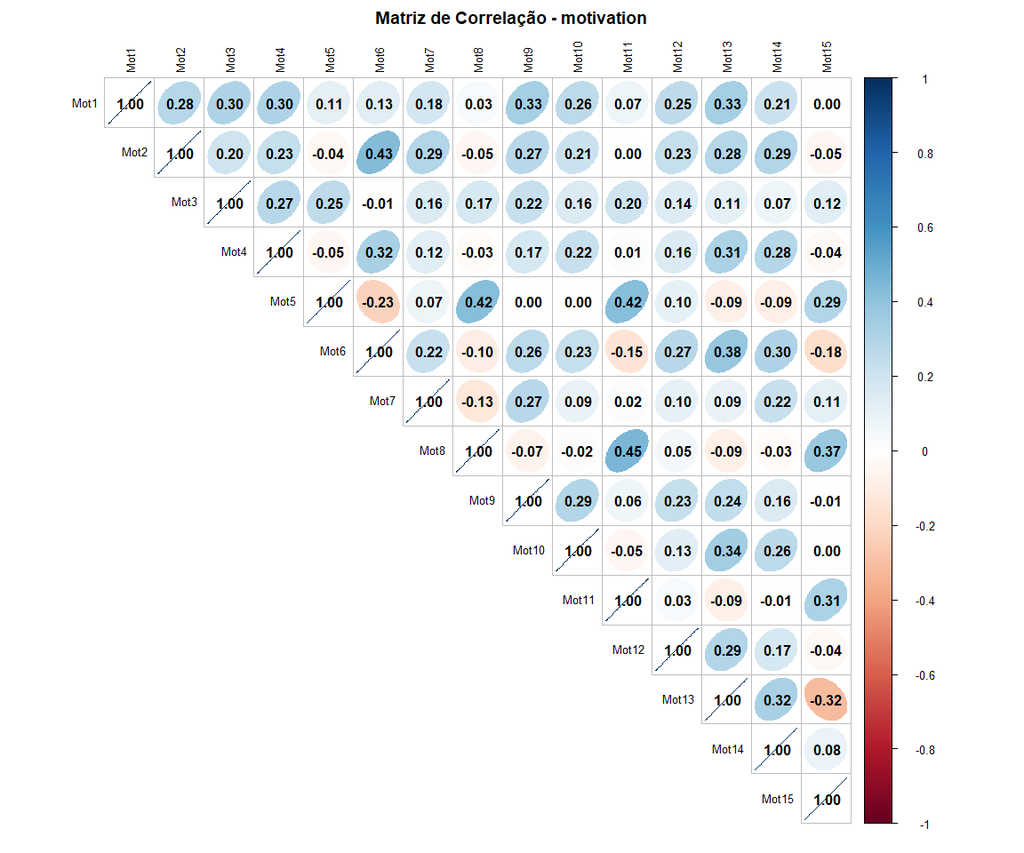

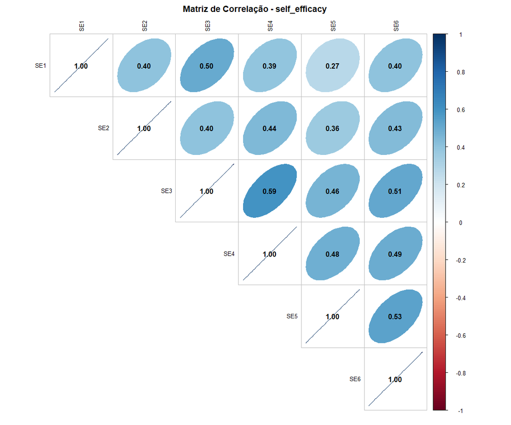

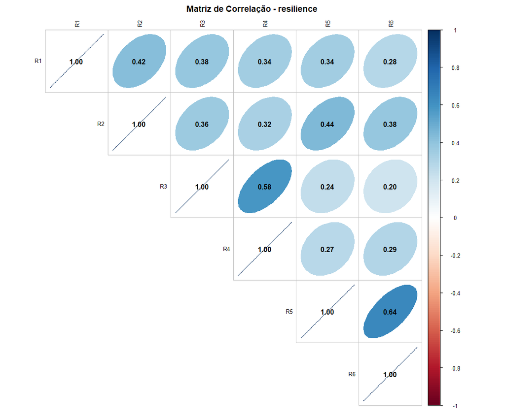

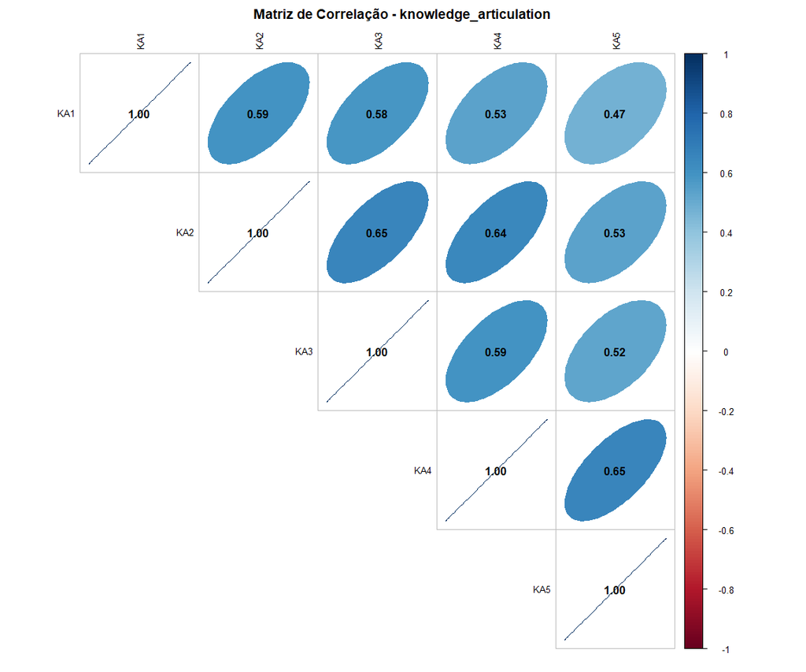

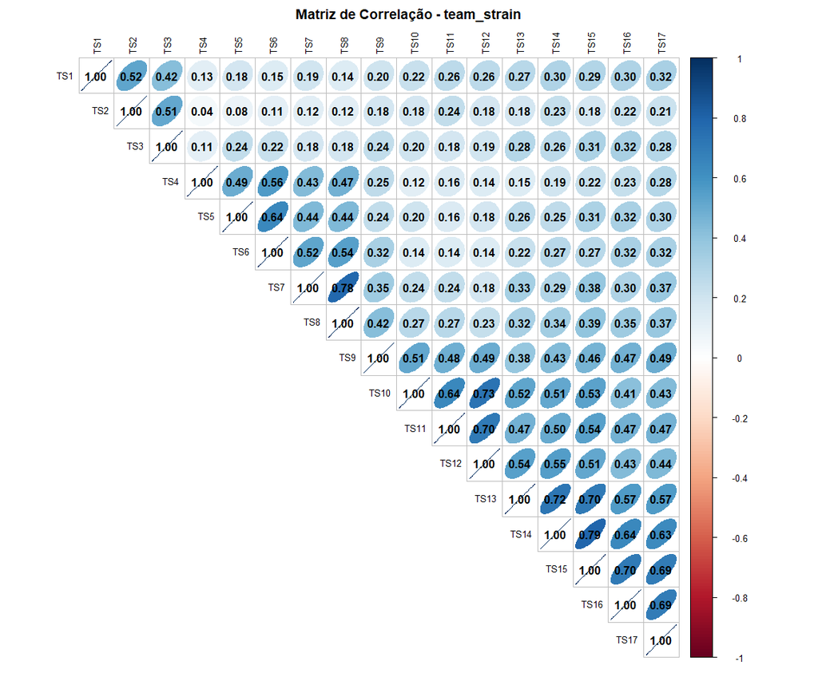

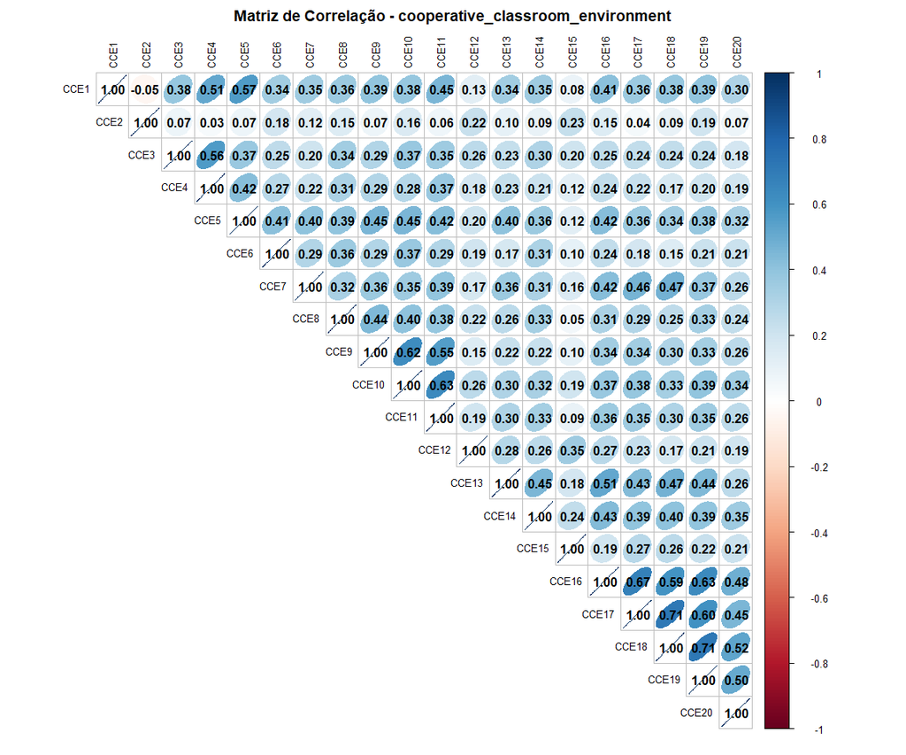

```r
construct_patterns <- list(
  ethical_behaviour = "^ET[1-9]$|^ET1[0-4]$",
  motivation = "^Mot[1-9]$|^Mot1[0-5]$",
  self_efficacy = "^SE[1-6]$",
  resilience = "^R[1-6]$",
  knowledge_articulation = "^KA[1-5]$",
  team_strain = "^TS[1-9]$|^TS1[0-7]$",
  cooperative_classroom_environment = "^CCE[1-9]$|^CCE1[0-9]$|^CCE20$"
)

for (name in names(construct_patterns)) {
  pattern <- construct_patterns[[name]]
  dataset <- df_transform %>% select(matches(pattern))

  if (ncol(dataset) >= 2) {
    corr_matrix <- round(cor(dataset, use = "pairwise.complete.obs"), 2)

    corrplot(corr_matrix,
             method = "ellipse",
             type = "upper",
             tl.col = "black",
             tl.cex = 0.8,
             addCoef.col = "black",
             number.cex = 1.0,
             mar = c(1, 1, 2, 1),
             title = paste("Matriz de Correlação -", name),
             width = 12,
             height = 10)
  }
}
```

#### Construtos

```r
calculate_metrics_all <- function(df, construct_patterns) {
  results <- list()

  for (name in names(construct_patterns)) {
    pattern <- construct_patterns[[name]]
    dataset <- df %>% select(matches(pattern))

    if (ncol(dataset) >= 2) {
      alpha_result <- alpha(dataset)
      cronbach_alpha <- alpha_result$total$raw_alpha

      fa_result <- fa(dataset, nfactors = 1, rotate = "none")
      loadings <- fa_result$loadings[, 1]

      results[[name]] <- list(
        construct = name,
        cronbach_alpha = cronbach_alpha,
        loadings = loadings
      )
    }
  }

  for (metric in results) {
    cat("\nConstruct: ", metric$construct, "\n")
    cat("Cronbach Alpha: ", round(metric$cronbach_alpha, 2), "\n")
    cat("Factor Loadings:\n")
    print(round(metric$loadings, 2))
  }

  return(results)
}
```

```r
metrics_results <- calculate_metrics_all(vars_artigo, construct_patterns)
```

```
## Some items ( Mot5 Mot8 Mot11 Mot15 ) were negatively correlated with the first principal component and
## probably should be reversed.
## To do this, run the function again with the 'check.keys=TRUE' option
## Construct:  ethical_behaviour
## Cronbach Alpha:  0.73
## Factor Loadings:
##  ET1  ET2  ET3  ET4  ET5  ET6  ET7  ET8  ET9 ET10 ET11 ET12 ET13 ET14
## 0.26 0.27 0.30 0.28 0.32 0.34 0.36 0.37 0.39 0.54 0.53 0.60 0.63 0.47
##
## Construct:  motivation
## Cronbach Alpha:  0.68
## Factor Loadings:
##  Mot1  Mot2  Mot3  Mot4  Mot5  Mot6  Mot7  Mot8  Mot9 Mot10 Mot11 Mot12 Mot13
##  0.50  0.57  0.28  0.49 -0.08  0.58  0.34 -0.11  0.49  0.46 -0.06  0.41  0.61
## Mot14 Mot15
##  0.48 -0.13
##
## Construct:  self_efficacy
## Cronbach Alpha:  0.82
## Factor Loadings:
##  SE1  SE2  SE3  SE4  SE5  SE6
## 0.57 0.59 0.76 0.74 0.63 0.71
##
## Construct:  resilience
## Cronbach Alpha:  0.78
## Factor Loadings:
##   R1   R2   R3   R4   R5   R6
## 0.58 0.65 0.57 0.58 0.65 0.60
##
## Construct:  knowledge_articulation
## Cronbach Alpha:  0.87
## Factor Loadings:
##  KA1  KA2  KA3  KA4  KA5
## 0.70 0.81 0.77 0.81 0.70
##
## Construct:  team_strain
## Cronbach Alpha:  0.89
## Factor Loadings:
##  TS1  TS2  TS3  TS4  TS5  TS6  TS7  TS8  TS9 TS10 TS11 TS12 TS13 TS14 TS15 TS16
## 0.40 0.31 0.40 0.39 0.46 0.47 0.53 0.57 0.63 0.65 0.65 0.66 0.73 0.78 0.82 0.74
## TS17
## 0.76
##
## Construct:  cooperative_classroom_environment
## Cronbach Alpha:  0.89
## Factor Loadings:
##  CCE1  CCE2  CCE3  CCE4  CCE5  CCE6  CCE7  CCE8  CCE9 CCE10 CCE11 CCE12 CCE13
##  0.63  0.17  0.49  0.47  0.66  0.44  0.58  0.54  0.58  0.66  0.62  0.36  0.58
## CCE14 CCE15 CCE16 CCE17 CCE18 CCE19 CCE20
##  0.57  0.29  0.72  0.70  0.68  0.70  0.55
```

```r
selected_construct_patterns <- list(
  ethical_behaviour = c("ET12", "ET13"),
  motivation = c("Mot5", "Mot8", "Mot11"),
  self_efficacy = c("SE1", "SE2", "SE3", "SE4", "SE5", "SE6"),
  resilience = c("R2", "R5", "R6"),
  knowledge_articulation = c("KA1", "KA2", "KA3", "KA4", "KA5"),
  team_strain = c("TS10", "TS11", "TS12", "TS13", "TS14", "TS15", "TS16", "TS17"),
  cooperative_classroom_environment = c("CCE1", "CCE3", "CCE4", "CCE5", "CCE8", "CCE9","CCE10", "CCE11")
)
metrics_results <- calculate_metrics_all(vars_artigo, selected_construct_patterns)
```

[output not shown]

### Análise das variáveis

#### Construtos criados no artigo

Ainda, temos acesso aos construtos criados pelos autores do artigo após a fase de análise fatorial. Vamos selecionar estas variáveis e guardá-las num objeto. Os construtos estão referidos na **Table 9** do artigo.

```r
construtos_autores <- df_transform[, 121:127]
construtos_autores
```

| ethics | Motivation | Resilience | SelfEfficacy | TeamStrain | KnowledgeArticulation | CoopClass |
| --- | --- | --- | --- | --- | --- | --- |
| 3.5 | 2.000000 | 4.000000 | 3.666667 | 3.125 | 3.6 | 3.750 |
| 5.0 | 3.000000 | 4.333333 | 4.000000 | 3.625 | 4.2 | 4.000 |
| 1.0 | 1.333333 | 5.000000 | 5.000000 | 4.000 | 4.2 | 4.125 |
| 2.0 | 3.000000 | 3.000000 | 3.000000 | 3.000 | 3.0 | 3.000 |
| 4.0 | 2.333333 | 4.000000 | 3.666667 | 3.625 | 2.8 | 3.875 |
| 3.5 | 2.333333 | 4.000000 | 3.833333 | 4.000 | 3.4 | 3.875 |
| 5.0 | 3.000000 | 4.333333 | 4.000000 | 3.625 | 4.2 | 4.000 |
| 3.5 | 4.000000 | 5.000000 | 4.000000 | 4.000 | 3.8 | 3.625 |
| 3.0 | 2.666667 | 2.666667 | 3.166667 | 3.000 | 4.0 | 3.625 |
| 4.0 | 3.333333 | 5.000000 | 3.666667 | 4.000 | 4.0 | 4.500 |

[output cut: 556 more lines]

| ethics <dbl> | Motivation <dbl> | Resilience <dbl> | SelfEfficacy <dbl> | TeamStrain <dbl> | KnowledgeArticulation <dbl> | CoopClass <dbl> |
| --- | --- | --- | --- | --- | --- | --- |
| 3.5 | 2.000000 | 4.000000 | 3.666667 | 3.125 | 3.6 | 3.750 |
| 5.0 | 3.000000 | 4.333333 | 4.000000 | 3.625 | 4.2 | 4.000 |
| 1.0 | 1.333333 | 5.000000 | 5.000000 | 4.000 | 4.2 | 4.125 |
| 2.0 | 3.000000 | 3.000000 | 3.000000 | 3.000 | 3.0 | 3.000 |
| 4.0 | 2.333333 | 4.000000 | 3.666667 | 3.625 | 2.8 | 3.875 |
| 3.5 | 2.333333 | 4.000000 | 3.833333 | 4.000 | 3.4 | 3.875 |
| 5.0 | 3.000000 | 4.333333 | 4.000000 | 3.625 | 4.2 | 4.000 |
| 3.5 | 4.000000 | 5.000000 | 4.000000 | 4.000 | 3.8 | 3.625 |
| 3.0 | 2.666667 | 2.666667 | 3.166667 | 3.000 | 4.0 | 3.625 |
| 4.0 | 3.333333 | 5.000000 | 3.666667 | 4.000 | 4.0 | 4.500 |

...

1-10 of 566 rows

#### Variáveis descritivas

Guardamos agora 8 variáveis do início do dataset que parecem ser apenas descritivas e que são referidas (algumas destas) no artigo, na tabela com as correlações. As correlações entre construtos pode ser encontrada na **Table 10** do artigo.

Uma destas variáveis é a `Fak` que já foi tratada anteriormente. Esta será incluída juntamente com as outras 7 e já terá os nomes alterados.

```r
descritivas <- df_transform[, 1:8]
descritivas
```

| Gender | Tlahir | BLhair | Pengeluaran | Status | Fak | IPK | Semester |
| --- | --- | --- | --- | --- | --- | --- | --- |
| 1 | 2000 | 2 | 1 | 2 | Economic | 4 | 1 |
| 1 | 2000 | 1 | 2 | 2 | Economic | 4 | 1 |
| 2 | 2000 | 10 | 2 | 2 | Economic | 4 | 1 |
| 1 | 2000 | 6 | 2 | 2 | Economic | 3 | 1 |
| 2 | 2000 | 9 | 1 | 2 | Mathematics and Natural Science | 3 | 1 |
| 1 | 2000 | 5 | 1 | 2 | Economic | 4 | 1 |
| 1 | 2000 | 1 | 2 | 2 | Economic | 4 | 1 |
| 1 | 1999 | 3 | 2 | 2 | Art | 4 | 1 |
| 1 | 2000 | 8 | 1 | 2 | Economic | 4 | 1 |
| 2 | 2000 | 6 | 4 | 2 | Mathematics and Natural Science | 2 | 1 |

[output cut: 556 more lines]

| Gender <int> | Tlahir <int> | BLhair <int> | Pengeluaran <int> | Status <int> | Fak <chr> | IPK <int> | Semester <int> |
| --- | --- | --- | --- | --- | --- | --- | --- |
| 1 | 2000 | 2 | 1 | 2 | Economic | 4 | 1 |
| 1 | 2000 | 1 | 2 | 2 | Economic | 4 | 1 |
| 2 | 2000 | 10 | 2 | 2 | Economic | 4 | 1 |
| 1 | 2000 | 6 | 2 | 2 | Economic | 3 | 1 |
| 2 | 2000 | 9 | 1 | 2 | Mathematics and Natural Science | 3 | 1 |
| 1 | 2000 | 5 | 1 | 2 | Economic | 4 | 1 |
| 1 | 2000 | 1 | 2 | 2 | Economic | 4 | 1 |
| 1 | 1999 | 3 | 2 | 2 | Art | 4 | 1 |
| 1 | 2000 | 8 | 1 | 2 | Economic | 4 | 1 |
| 2 | 2000 | 6 | 4 | 2 | Mathematics and Natural Science | 2 | 1 |

...

1-10 of 566 rows

```r
skimr::skim(descritivas)$skim_variable
```

```
## [1] "Fak"         "Gender"      "Tlahir"      "BLhair"      "Pengeluaran"
## [6] "Status"      "IPK"         "Semester"
```

```r
skimr::skim(descritivas)$numeric.p0
```

```
## [1]   NA    1 1995    0    1    1    1    1
```

```r
skimr::skim(descritivas)$numeric.p100
```

```
## [1]       NA        2 31031999       12        5        3        4        6
```

Após alguma pesquisa fomos tentar verificar o que representavam estas variáveis.

- **Género**:Género da pessoa (pode ser 1 ou 2). À partida não sabemos qual corresponde ao feminino e ao masculino.
- **Tlahir**: Em indonésio pode ser uma abreviatura de Tanggal Lahir, que significa data de nascimento.
- **BLhair**: Em indonésio pode ser uma abreviatura de Bulan Lahir, que significa mês de nascimento.
- *Pengeluaran**: Em indonésio pode ser uma abreviatura de Pengeluaran, que significa despesas. Tradução direta para inglês $rightarrow$ Expenditure.

Verificamos o mínimo e o máximo de cada variável descritiva e percebemos alguns valores estranhos, dado o contexto pesquisado. Um deles é por exemplo o `Tlahir`. Talvez o valor mais alto $\rightarrow 31031999$ corresponde a $31/03/1999$. Para além disso o mês `BLhair` tem valores de 0 a 12, pelo que o 0 não faz muito sentido.

Estes valores não vão ser alterados, por enquanto, porque não serão importantes para a análise e replicação dos resultados.

#### Variáveis não citadas no artigo

As colunas que não estão nos outros datasets.

```r
# selecionar do dataset df_transform aquelas que não estao em descritivas, vars_artigo e construtos_autores
vars_nao_citadas <- df_transform %>%
  select(-all_of(c(colnames(descritivas), colnames(vars_artigo), colnames(construtos_autores))))
vars_nao_citadas
```

| POP1 | POP2 | POP3 | POP4 | POP5 | POP6 | POP7 | POP8 | POP9 | PC1 | PC2 | PC3 | PC4 | PC5 | PC6 | Opt1 | Opt2 | Opt3 | Opt4 | Opt5 | Opt6 | INO1 | INO2 | INO3 | INO4 | INO5 | PDC1 | PDC2 | PDC3 |
| --- | --- | --- | --- | --- | --- | --- | --- | --- | --- | --- | --- | --- | --- | --- | --- | --- | --- | --- | --- | --- | --- | --- | --- | --- | --- | --- | --- | --- |
| 4 | 4 | 4 | 4 | 4 | 4 | 4 | 4 | 1 | 4 | 4 | 4 | 3 | 4 | 4 | 3 | 4 | 3 | 4 | 4 | 4 | 4 | 3 | 3 | 3 | 3 | 4 | 4 | 3 |
| 4 | 4 | 4 | 3 | 3 | 4 | 4 | 3 | 3 | 4 | 5 | 5 | 3 | 4 | 3 | 3 | 4 | 3 | 3 | 3 | 3 | 4 | 4 | 4 | 4 | 4 | 4 | 4 | 4 |
| 5 | 5 | 5 | 1 | 1 | 5 | 1 | 3 | 1 | 5 | 5 | 5 | 5 | 5 | 5 | 1 | 5 | 1 | 5 | 5 | 5 | 5 | 4 | 5 | 5 | 5 | 4 | 5 | 5 |
| 4 | 4 | 3 | 3 | 3 | 5 | 5 | 3 | 3 | 3 | 3 | 3 | 3 | 3 | 3 | 3 | 3 | 3 | 3 | 3 | 3 | 4 | 4 | 2 | 3 | 3 | 3 | 3 | 3 |
| 2 | 3 | 3 | 4 | 3 | 4 | 4 | 3 | 3 | 4 | 4 | 4 | 3 | 4 | 4 | 3 | 4 | 3 | 4 | 4 | 3 | 4 | 4 | 4 | 3 | 3 | 4 | 4 | 4 |
| 5 | 4 | 4 | 4 | 4 | 4 | 4 | 4 | 2 | 5 | 5 | 5 | 3 | 5 | 3 | 5 | 5 | 4 | 4 | 5 | 4 | 4 | 4 | 3 | 4 | 4 | 3 | 5 | 5 |
| 4 | 4 | 4 | 3 | 3 | 4 | 4 | 3 | 3 | 4 | 5 | 5 | 3 | 4 | 3 | 3 | 4 | 3 | 3 | 3 | 3 | 4 | 4 | 4 | 4 | 4 | 4 | 4 | 4 |
| 4 | 3 | 4 | 4 | 3 | 4 | 4 | 4 | 4 | 4 | 4 | 4 | 4 | 4 | 4 | 4 | 4 | 4 | 4 | 4 | 4 | 3 | 2 | 4 | 3 | 3 | 3 | 4 | 4 |
| 1 | 1 | 3 | 1 | 4 | 4 | 2 | 1 | 1 | 4 | 4 | 4 | 3 | 4 | 3 | 1 | 1 | 4 | 3 | 4 | 3 | 4 | 3 | 4 | 4 | 4 | 4 | 4 | 4 |
| 4 | 4 | 4 | 2 | 2 | 4 | 4 | 3 | 2 | 3 | 4 | 4 | 4 | 4 | 4 | 4 | 3 | 4 | 4 | 4 | 3 | 3 | 4 | 4 | 4 | 4 | 4 | 4 | 4 |

[output cut: 556 more lines]

| POP1 <int> | POP2 <int> | POP3 <int> | POP4 <int> | POP5 <int> | POP6 <int> | POP7 <int> | POP8 <int> | POP9 <int> | PC1 <int> |  |
| --- | --- | --- | --- | --- | --- | --- | --- | --- | --- | --- |
| 4 | 4 | 4 | 4 | 4 | 4 | 4 | 4 | 1 | 4 |  |
| 4 | 4 | 4 | 3 | 3 | 4 | 4 | 3 | 3 | 4 |  |
| 5 | 5 | 5 | 1 | 1 | 5 | 1 | 3 | 1 | 5 |  |
| 4 | 4 | 3 | 3 | 3 | 5 | 5 | 3 | 3 | 3 |  |
| 2 | 3 | 3 | 4 | 3 | 4 | 4 | 3 | 3 | 4 |  |
| 5 | 4 | 4 | 4 | 4 | 4 | 4 | 4 | 2 | 5 |  |
| 4 | 4 | 4 | 3 | 3 | 4 | 4 | 3 | 3 | 4 |  |
| 4 | 3 | 4 | 4 | 3 | 4 | 4 | 4 | 4 | 4 |  |
| 1 | 1 | 3 | 1 | 4 | 4 | 2 | 1 | 1 | 4 |  |
| 4 | 4 | 4 | 2 | 2 | 4 | 4 | 3 | 2 | 3 |  |

...

1-10 of 566 rows | 1-10 of 29 columns

#### Criar ficheiros csv na pasta data com os 4 conjuntos anteriores

```r
# escrever uma função
write_csvs <- function(data, name){
  write_csv(data, paste0("../data/4_conjuntos(dev)/", name, ".csv"))
}
write_csvs(descritivas, "descritivas")
write_csvs(vars_artigo, "vars_artigo")
write_csvs(construtos_autores, "construtos_autores")
write_csvs(vars_nao_citadas, "vars_nao_citadas")
```

## Fase 2: Replicação do artigo

### 1 - CFA para cada conjunto de questões

```r
# ler csv
df <- read_csv("../data/4_conjuntos(dev)/vars_artigo.csv")
df
```

| ET1 | ET2 | ET3 | ET4 | ET5 | ET6 | ET7 | ET8 | ET9 | ET10 | ET11 | ET12 | ET13 | ET14 | Mot1 | Mot2 | Mot3 | Mot4 | Mot5 | Mot6 | Mot7 | Mot8 | Mot9 | Mot10 | Mot11 | Mot12 | Mot13 | Mot14 | Mot15 | SE1 | … |
| --- | --- | --- | --- | --- | --- | --- | --- | --- | --- | --- | --- | --- | --- | --- | --- | --- | --- | --- | --- | --- | --- | --- | --- | --- | --- | --- | --- | --- | --- | --- |
| 1 | 4 | 4 | 3 | 1 | 1 | 3 | 3 | 4 | 4 | 4 | 3 | 4 | 4 | 3 | 4 | 4 | 4 | 2 | 4 | 4 | 2 | 4 | 4 | 2 | 4 | 4 | 4 | 2 | 3 | … |
| 1 | 2 | 1 | 2 | 2 | 2 | 5 | 5 | 5 | 5 | 5 | 5 | 5 | 4 | 4 | 4 | 4 | 5 | 3 | 5 | 4 | 3 | 4 | 4 | 3 | 4 | 5 | 5 | 1 | 4 | … |
| 1 | 1 | 1 | 5 | 1 | 1 | 5 | 5 | 5 | 1 | 1 | 1 | 1 | 1 | 4 | 5 | 2 | 2 | 2 | 5 | 5 | 1 | 1 | 5 | 1 | 4 | 5 | 5 | 1 | 5 | … |
| 1 | 4 | 1 | 1 | 1 | 3 | 4 | 4 | 5 | 5 | 4 | 2 | 2 | 2 | 4 | 4 | 4 | 3 | 2 | 4 | 2 | 4 | 3 | 3 | 3 | 4 | 5 | 3 | 1 | 3 | … |
| 3 | 3 | 2 | 3 | 3 | 3 | 4 | 4 | 5 | 4 | 4 | 4 | 4 | 3 | 4 | 3 | 2 | 4 | 2 | 4 | 4 | 2 | 4 | 3 | 3 | 4 | 4 | 4 | 3 | 4 | … |
| 2 | 3 | 1 | 2 | 2 | 2 | 4 | 4 | 4 | 2 | 3 | 3 | 4 | 5 | 4 | 4 | 3 | 3 | 3 | 4 | 4 | 1 | 4 | 3 | 3 | 4 | 5 | 4 | 1 | 4 | … |
| 1 | 2 | 1 | 2 | 2 | 2 | 5 | 5 | 5 | 5 | 5 | 5 | 5 | 4 | 4 | 4 | 4 | 5 | 3 | 5 | 4 | 3 | 4 | 4 | 3 | 4 | 5 | 5 | 1 | 4 | … |
| 4 | 4 | 3 | 4 | 4 | 3 | 4 | 4 | 4 | 5 | 3 | 4 | 3 | 4 | 4 | 4 | 4 | 4 | 4 | 4 | 4 | 4 | 4 | 4 | 4 | 4 | 4 | 4 | 5 | 4 | … |
| 1 | 4 | 4 | 4 | 1 | 1 | 4 | 4 | 4 | 4 | 3 | 3 | 3 | 4 | 5 | 5 | 3 | 4 | 2 | 4 | 3 | 2 | 4 | 4 | 4 | 5 | 5 | 4 | 1 | 4 | … |
| 2 | 5 | 2 | 3 | 3 | 3 | 5 | 5 | 4 | 5 | 4 | 4 | 4 | 5 | 4 | 4 | 4 | 4 | 3 | 5 | 4 | 4 | 5 | 5 | 3 | 5 | 5 | 5 | 3 | 4 | … |

[output cut: 556 more lines]

| ET1 <dbl> | ET2 <dbl> | ET3 <dbl> | ET4 <dbl> | ET5 <dbl> | ET6 <dbl> | ET7 <dbl> | ET8 <dbl> | ET9 <dbl> | ET10 <dbl> |  |
| --- | --- | --- | --- | --- | --- | --- | --- | --- | --- | --- |
| 1 | 4 | 4 | 3 | 1 | 1 | 3 | 3 | 4 | 4 |  |
| 1 | 2 | 1 | 2 | 2 | 2 | 5 | 5 | 5 | 5 |  |
| 1 | 1 | 1 | 5 | 1 | 1 | 5 | 5 | 5 | 1 |  |
| 1 | 4 | 1 | 1 | 1 | 3 | 4 | 4 | 5 | 5 |  |
| 3 | 3 | 2 | 3 | 3 | 3 | 4 | 4 | 5 | 4 |  |
| 2 | 3 | 1 | 2 | 2 | 2 | 4 | 4 | 4 | 2 |  |
| 1 | 2 | 1 | 2 | 2 | 2 | 5 | 5 | 5 | 5 |  |
| 4 | 4 | 3 | 4 | 4 | 3 | 4 | 4 | 4 | 5 |  |
| 1 | 4 | 4 | 4 | 1 | 1 | 4 | 4 | 4 | 4 |  |
| 2 | 5 | 2 | 3 | 3 | 3 | 5 | 5 | 4 | 5 |  |

...

1-10 of 566 rows | 1-10 of 83 columns

Como primeira análise vamos fazer uma análise fatorial confirmatória (CFA) para tentar verificar se as variáveis utilizadas nos construtos são as que têm valores de loadings mais elevados. Vamos usar o pacote `blavaan` para fazer a modelação bayesiana.

```r
# individual params
n_chains <- 3 # 5
burn_in <- 1500
sample_estimate <- 3000
```

```r
plot_sem_model <- function(model, title = "") {
  semPaths(model,
           what = "std",
           layout = "spring",
           edge.label.cex = 0.8,
           sizeMan = 5,
           sizeLat = 7,
           nCharNodes = 0,
           residuals = TRUE,
           intercepts = FALSE,
           optimizeLatRes = TRUE,
           edge.color = "darkgreen",
           color = list(lat = "skyblue", man = "white"),
           node.width = 2,
           mar = c(6, 6, 6, 6))
}
```

#### CFA com todas as variáveis para tentar justificar/perceber as escolhas para os construtos

##### Student Ethics

```r
# Student Ethics
model.ethics <- 'StudentEthics =~ ET1 + ET2 + ET3 + ET4 + ET5 + ET6 + ET7 +
                                  ET8 + ET9 + ET10 + ET11 + ET12 + ET13 + ET14'
fit.ethics <- bcfa(model.ethics, data = df, std.lv = TRUE,
                      n.chains = n_chains, burnin=burn_in,
                      sample=sample_estimate, target = "stan")
```

```
##
##
##
## Computing post-estimation metrics (including lvs if requested)...
```

```r
summary(fit.ethics, standardized = TRUE, rsquare = TRUE)
```

```
## blavaan 0.5.8 ended normally after 3000 iterations
##
##   Estimator                                      BAYES
##   Optimization method                             MCMC
##   Number of model parameters                        28
##
##   Number of observations                           566
##
##   Statistic                                 MargLogLik         PPP
##   Value                                     -10180.825       0.000
##
## Parameter Estimates:
##
##
## Latent Variables:
##                    Estimate  Post.SD pi.lower pi.upper   Std.lv  Std.all
##   StudentEthics =~
##     ET1               0.183    0.043    0.098    0.268    0.183    0.204
##     ET2               0.243    0.064    0.119    0.370    0.243    0.185
##     ET3               0.258    0.048    0.163    0.353    0.258    0.261
##     ET4               0.221    0.045    0.133    0.309    0.221    0.236
##     ET5               0.275    0.050    0.178    0.375    0.275    0.269
##     ET6               0.289    0.046    0.198    0.380    0.289    0.298
##     ET7               0.199    0.042    0.117    0.284    0.199    0.247
##     ET8               0.195    0.041    0.115    0.277    0.195    0.252
##     ET9               0.191    0.038    0.118    0.269    0.191    0.268
##     ET10              0.396    0.042    0.314    0.478    0.396    0.458
##     ET11              0.412    0.038    0.339    0.489    0.412    0.503
##     ET12              0.741    0.043    0.654    0.824    0.741    0.780
##     ET13              0.749    0.042    0.664    0.830    0.749    0.795
##     ET14              0.364    0.042    0.281    0.448    0.364    0.406
##      Rhat    Prior
##
##     1.000    normal(0,10)
##     1.000    normal(0,10)
##     1.000    normal(0,10)
##     1.000    normal(0,10)
##     1.000    normal(0,10)
##     1.000    normal(0,10)
##     1.000    normal(0,10)
```

[output cut: 43 more lines]

```
##                    Estimate
##     ET1               0.042
##     ET2               0.034
##     ET3               0.068
##     ET4               0.056
##     ET5               0.072
##     ET6               0.089
##     ET7               0.061
##     ET8               0.064
##     ET9               0.072
##     ET10              0.210
##     ET11              0.253
##     ET12              0.609
##     ET13              0.632
##     ET14              0.165
```

```r
fitMeasures(fit.ethics)
```

```
##       npar       logl        ppp        bic        dic      p_dic       waic
##     28.000 -10057.983      0.000  20293.396  20172.138     28.086  20200.636
##     p_waic    se_waic      looic      p_loo     se_loo margloglik
##     57.457    246.598  20201.406     57.842    246.724 -10180.825
```

1500 burn-in + 3000 samples

| Item | Loadings |
| --- | --- |
| ET1 | 0.183 |
| ET2 | 0.244 |
| ET3 | 0.258 |
| ET4 | 0.221 |
| ET5 | 0.275 |
| ET6 | 0.288 |
| ET7 | 0.198 |
| ET8 | 0.194 |
| ET9 | 0.190 |
| ET10 | 0.395 |
| ET11 | 0.411 |
| ET12 | **0.741** |
| ET13 | **0.749** |
| ET14 | 0.364 |

O artigo opta por selecionar apenas 2 variáveis para o `Student Ethics` (ET12 e ET13), que são os que têm os loadings mais expressivos.

##### Motivation

```r
# Motivation
model.motivation <- 'Motivation =~ Mot1 + Mot2 + Mot3 + Mot4 + Mot5 +
                                  Mot6 + Mot7 + Mot8 + Mot9 + Mot10 +
                                  Mot11 + Mot12 + Mot13 + Mot14 +
                                  Mot15'
fit.motivation <- bcfa(model.motivation, data = df, std.lv = TRUE,
                      n.chains = n_chains, burnin=burn_in,
                      sample=sample_estimate, target = "stan")
```

```
##
##
##
## Computing post-estimation metrics (including lvs if requested)...
```

```r
summary(fit.motivation, standardized = TRUE, rsquare = TRUE)
```

```
## blavaan 0.5.8 ended normally after 3000 iterations
##
##   Estimator                                      BAYES
##   Optimization method                             MCMC
##   Number of model parameters                        30
##
##   Number of observations                           566
##
##   Statistic                                 MargLogLik         PPP
##   Value                                      -9592.072       0.000
##
## Parameter Estimates:
##
##
## Latent Variables:
##                    Estimate  Post.SD pi.lower pi.upper   Std.lv  Std.all
##   Motivation =~
##     Mot1              0.364    0.034    0.299    0.431    0.364    0.498
##     Mot2              0.387    0.030    0.328    0.445    0.387    0.574
##     Mot3              0.244    0.043    0.160    0.328    0.244    0.280
##     Mot4              0.367    0.033    0.303    0.433    0.367    0.497
##     Mot5             -0.078    0.044   -0.166    0.009   -0.078   -0.089
##     Mot6              0.409    0.031    0.350    0.472    0.409    0.594
##     Mot7              0.259    0.036    0.188    0.330    0.259    0.344
##     Mot8             -0.101    0.046   -0.192   -0.010   -0.101   -0.111
##     Mot9              0.354    0.034    0.289    0.421    0.354    0.485
##     Mot10             0.318    0.031    0.258    0.379    0.318    0.462
##     Mot11            -0.059    0.047   -0.151    0.034   -0.059   -0.063
##     Mot12             0.285    0.032    0.222    0.347    0.285    0.414
##     Mot13             0.422    0.030    0.364    0.482    0.422    0.615
##     Mot14             0.354    0.033    0.291    0.420    0.354    0.487
##     Mot15            -0.166    0.055   -0.275   -0.057   -0.166   -0.149
##      Rhat    Prior
##
##     1.000    normal(0,10)
##     1.000    normal(0,10)
##     1.000    normal(0,10)
##     1.000    normal(0,10)
##     1.000    normal(0,10)
##     1.000    normal(0,10)
```

[output cut: 48 more lines]

```
##     Mot1              0.248
##     Mot2              0.329
##     Mot3              0.079
##     Mot4              0.247
##     Mot5              0.008
##     Mot6              0.353
##     Mot7              0.118
##     Mot8              0.012
##     Mot9              0.235
##     Mot10             0.214
##     Mot11             0.004
##     Mot12             0.171
##     Mot13             0.378
##     Mot14             0.237
##     Mot15             0.022
```

```r
fitMeasures(fit.motivation)
```

```
##       npar       logl        ppp        bic        dic      p_dic       waic
##     30.000  -9454.842      0.000  19099.789  18969.752     30.034  18992.486
##     p_waic    se_waic      looic      p_loo     se_loo margloglik
##     51.780    261.357  18992.379     51.727    261.332  -9592.072
```

1500 burn-in + 3000 samples

| Item | Loadings |
| --- | --- |
| Mot1 | 0.364 |
| Mot2 | 0.386 |
| Mot3 | 0.244 |
| Mot4 | 0.368 |
| Mot5 | -0.078 |
| Mot6 | 0.409 |
| Mot7 | 0.259 |
| Mot8 | -0.101 |
| Mot9 | 0.354 |
| Mot10 | 0.318 |
| Mot11 | -0.058 |
| Mot12 | 0.285 |
| Mot13 | 0.422 |
| Mot14 | 0.354 |
| Mot15 | -0.165 |

O artigo opta por selecionar apenas 3 variáveis para o `Motivation` (Mot5, Mot8 e Mot11), que são os que têm os loadings negativos, a par do Mot15. São as três variáveis que têm os loadings mais parto de 0 (com diferença menor que 0.1), que talvez seja uma forma de tentar perceber a relação entre a pouca motivação e a ética.

##### Self-Efficacy

```r
# Self-Efficacy
model.efficacy <- 'SelfEfficacy =~ SE1 + SE2 + SE3 + SE4 + SE5 + SE6'
fit.efficacy <- bcfa(model.efficacy, data = df, std.lv = TRUE,
                      n.chains = n_chains, burnin=burn_in,
                      sample=sample_estimate, target = "stan")
```

```
##
##
##
## Computing post-estimation metrics (including lvs if requested)...
```

```r
summary(fit.efficacy, standardized = TRUE, rsquare = TRUE)
```

```
## blavaan 0.5.8 ended normally after 3000 iterations
##
##   Estimator                                      BAYES
##   Optimization method                             MCMC
##   Number of model parameters                        12
##
##   Number of observations                           566
##
##   Statistic                                 MargLogLik         PPP
##   Value                                      -3092.362       0.000
##
## Parameter Estimates:
##
##
## Latent Variables:
##                    Estimate  Post.SD pi.lower pi.upper   Std.lv  Std.all
##   SelfEfficacy =~
##     SE1               0.414    0.030    0.356    0.474    0.414    0.578
##     SE2               0.447    0.032    0.384    0.510    0.447    0.584
##     SE3               0.514    0.026    0.462    0.566    0.514    0.762
##     SE4               0.494    0.026    0.443    0.546    0.494    0.741
##     SE5               0.441    0.029    0.386    0.497    0.441    0.638
##     SE6               0.458    0.026    0.407    0.511    0.458    0.705
##      Rhat    Prior
##
##     1.000    normal(0,10)
##     1.000    normal(0,10)
##     1.000    normal(0,10)
##     1.000    normal(0,10)
##     1.000    normal(0,10)
##     1.000    normal(0,10)
##
## Variances:
##                    Estimate  Post.SD pi.lower pi.upper   Std.lv  Std.all
##    .SE1               0.343    0.023    0.301    0.390    0.343    0.666
##    .SE2               0.385    0.025    0.339    0.436    0.385    0.659
##    .SE3               0.191    0.016    0.162    0.223    0.191    0.420
##    .SE4               0.201    0.016    0.171    0.232    0.201    0.451
##    .SE5               0.283    0.019    0.247    0.323    0.283    0.593
##    .SE6               0.212    0.016    0.182    0.245    0.212    0.503
##     SelfEfficacy      1.000                               1.000    1.000
##      Rhat    Prior
##     1.000 gamma(1,.5)[sd]
##     1.000 gamma(1,.5)[sd]
##     1.000 gamma(1,.5)[sd]
##     1.000 gamma(1,.5)[sd]
##     1.000 gamma(1,.5)[sd]
##     1.000 gamma(1,.5)[sd]
##
##
## R-Square:
##                    Estimate
##     SE1               0.334
##     SE2               0.341
##     SE3               0.580
##     SE4               0.549
##     SE5               0.407
##     SE6               0.497
```

```r
fitMeasures(fit.efficacy)
```

```
##       npar       logl        ppp        bic        dic      p_dic       waic
##     12.000  -3033.293      0.000   6142.627   6090.500     11.957   6099.079
##     p_waic    se_waic      looic      p_loo     se_loo margloglik
##     20.216    162.027   6099.134     20.243    162.036  -3092.362
```

1500 burn-in + 3000 samples

| Item | Loadings |
| --- | --- |
| SE1 | 0.414 |
| SE2 | 0.447 |
| SE3 | 0.514 |
| SE4 | 0.494 |
| SE5 | 0.441 |
| SE6 | 0.458 |

Optam-se por utilizar todas as variáveis para o `Self Efficacy`, dado que todas têm loadings positivos e acima de 0.4.

##### Resilience

```r
# Resilience
model.resilience <- 'Resilience =~ R1 + R2 + R3 + R4 + R5 + R6'
fit.resilience <- bcfa(model.resilience, data = df, std.lv = TRUE,
                      n.chains = n_chains, burnin=burn_in,
                      sample=sample_estimate, target = "stan")
```

```
##
##
##
## Computing post-estimation metrics (including lvs if requested)...
```

```r
summary(fit.resilience, standardized = TRUE, rsquare = TRUE)
```

```
## blavaan 0.5.8 ended normally after 3000 iterations
##
##   Estimator                                      BAYES
##   Optimization method                             MCMC
##   Number of model parameters                        12
##
##   Number of observations                           566
##
##   Statistic                                 MargLogLik         PPP
##   Value                                      -3502.237       0.000
##
## Parameter Estimates:
##
##
## Latent Variables:
##                    Estimate  Post.SD pi.lower pi.upper   Std.lv  Std.all
##   Resilience =~
##     R1                0.438    0.035    0.371    0.508    0.438    0.565
##     R2                0.501    0.034    0.436    0.569    0.501    0.643
##     R3                0.356    0.034    0.291    0.422    0.356    0.531
##     R4                0.381    0.033    0.317    0.448    0.381    0.551
##     R5                0.548    0.038    0.473    0.623    0.548    0.687
##     R6                0.485    0.036    0.415    0.556    0.485    0.642
##      Rhat    Prior
##
##     1.000    normal(0,10)
##     1.000    normal(0,10)
##     1.000    normal(0,10)
##     1.000    normal(0,10)
##     1.000    normal(0,10)
##     1.000    normal(0,10)
##
## Variances:
##                    Estimate  Post.SD pi.lower pi.upper   Std.lv  Std.all
##    .R1                0.410    0.030    0.354    0.472    0.410    0.681
##    .R2                0.357    0.027    0.306    0.414    0.357    0.587
##    .R3                0.323    0.025    0.277    0.374    0.323    0.718
##    .R4                0.333    0.024    0.287    0.383    0.333    0.696
##    .R5                0.336    0.032    0.274    0.401    0.336    0.529
##    .R6                0.336    0.029    0.282    0.397    0.336    0.588
##     Resilience        1.000                               1.000    1.000
##      Rhat    Prior
##     1.000 gamma(1,.5)[sd]
##     1.000 gamma(1,.5)[sd]
##     1.000 gamma(1,.5)[sd]
##     1.000 gamma(1,.5)[sd]
##     1.000 gamma(1,.5)[sd]
##     1.000 gamma(1,.5)[sd]
##
##
## R-Square:
##                    Estimate
##     R1                0.319
##     R2                0.413
##     R3                0.282
##     R4                0.304
##     R5                0.471
##     R6                0.412
```

```r
fitMeasures(fit.resilience)
```

```
##       npar       logl        ppp        bic        dic      p_dic       waic
##     12.000  -3445.917      0.000   6967.875   6915.659     11.913   6926.187
##     p_waic    se_waic      looic      p_loo     se_loo margloglik
##     22.079    162.481   6926.173     22.072    162.477  -3502.237
```

1500 burn-in + 3000 samples

| Item | Loadings |
| --- | --- |
| R1 | 0.438 |
| R2 | 0.501 |
| R3 | 0.356 |
| R4 | 0.381 |
| R5 | 0.548 |
| R6 | 0.485 |

O artigo opta por selecionar 3 variáveis para o `Resilience` (R2, R5 e R6), que são os que têm os loadings mais expressivos (os três arredondados são acima 0.5).

##### Knowledge Articulation

```r
# Knowledge Articulation
model.knowledge <- 'KnowledgeArticulation =~ KA1 + KA2 + KA3 + KA4 + KA5'
fit.knowledge <- bcfa(model.knowledge, data = df, std.lv = TRUE,
                      n.chains = n_chains, burnin=burn_in,
                      sample=sample_estimate, target = "stan")
```

```
##
##
##
## Computing post-estimation metrics (including lvs if requested)...
```

```r
summary(fit.knowledge, standardized = TRUE, rsquare = TRUE)
```

```
## blavaan 0.5.8 ended normally after 3000 iterations
##
##   Estimator                                      BAYES
##   Optimization method                             MCMC
##   Number of model parameters                        10
##
##   Number of observations                           566
##
##   Statistic                                 MargLogLik         PPP
##   Value                                      -2156.761       0.000
##
## Parameter Estimates:
##
##
## Latent Variables:
##                            Estimate  Post.SD pi.lower pi.upper   Std.lv
##   KnowledgeArticulation =~
##     KA1                       0.476    0.026    0.426    0.529    0.476
##     KA2                       0.522    0.024    0.476    0.568    0.522
##     KA3                       0.477    0.023    0.433    0.523    0.477
##     KA4                       0.511    0.024    0.465    0.557    0.511
##     KA5                       0.450    0.025    0.402    0.499    0.450
##   Std.all     Rhat    Prior
##
##     0.704    1.000    normal(0,10)
##     0.807    1.000    normal(0,10)
##     0.774    1.000    normal(0,10)
##     0.801    1.000    normal(0,10)
##     0.709    1.000    normal(0,10)
##
## Variances:
##                    Estimate  Post.SD pi.lower pi.upper   Std.lv  Std.all
##    .KA1               0.231    0.016    0.201    0.265    0.231    0.504
##    .KA2               0.146    0.012    0.124    0.170    0.146    0.349
##    .KA3               0.153    0.012    0.131    0.178    0.153    0.401
##    .KA4               0.145    0.012    0.122    0.170    0.145    0.358
##    .KA5               0.200    0.014    0.173    0.230    0.200    0.498
##     KnowldgArtcltn    1.000                               1.000    1.000
##      Rhat    Prior
##     1.000 gamma(1,.5)[sd]
##     1.000 gamma(1,.5)[sd]
##     1.000 gamma(1,.5)[sd]
##     1.000 gamma(1,.5)[sd]
##     1.000 gamma(1,.5)[sd]
##
##
## R-Square:
##                    Estimate
##     KA1               0.496
##     KA2               0.651
##     KA3               0.599
##     KA4               0.642
##     KA5               0.502
```

```r
fitMeasures(fit.knowledge)
```

```
##       npar       logl        ppp        bic        dic      p_dic       waic
##     10.000  -2105.026      0.000   4273.421   4229.976      9.961   4252.906
##     p_waic    se_waic      looic      p_loo     se_loo margloglik
##     31.780    195.597   4252.970     31.812    195.625  -2156.761
```

1500 burn-in + 3000 samples

| Item | Loadings |
| --- | --- |
| KA1 | 0.476 |
| KA2 | 0.521 |
| KA3 | 0.476 |
| KA4 | 0.510 |
| KA5 | 0.449 |

O artigo opta por selecionar todas as variáveis para o `Knowledge Articulation`, dado que todas têm loadings positivos e acima de 0.4.

##### Team Strain

```r
# Team Strain
model.teamstrain <- 'TeamStrain =~ TS1 + TS2 + TS3 + TS4 + TS5 +
                                  TS6 + TS7 + TS8 + TS9 + TS10 +
                                  TS11 + TS12 + TS13 + TS14 +
                                  TS15 + TS16 + TS17'
fit.teamstrain <- bcfa(model.teamstrain, data = df, std.lv = TRUE,
                      n.chains = n_chains, burnin=burn_in,
                      sample=sample_estimate, target = "stan")
```

```
##
##
##
## Computing post-estimation metrics (including lvs if requested)...
```

```r
summary(fit.teamstrain, standardized = TRUE, rsquare = TRUE)
```

```
## blavaan 0.5.8 ended normally after 3000 iterations
##
##   Estimator                                      BAYES
##   Optimization method                             MCMC
##   Number of model parameters                        34
##
##   Number of observations                           566
##
##   Statistic                                 MargLogLik         PPP
##   Value                                      -8488.216       0.000
##
## Parameter Estimates:
##
##
## Latent Variables:
##                    Estimate  Post.SD pi.lower pi.upper   Std.lv  Std.all
##   TeamStrain =~
##     TS1               0.294    0.033    0.232    0.359    0.294    0.386
##     TS2               0.216    0.033    0.153    0.282    0.216    0.288
##     TS3               0.266    0.030    0.207    0.325    0.266    0.377
##     TS4               0.245    0.033    0.181    0.309    0.245    0.322
##     TS5               0.284    0.030    0.224    0.345    0.284    0.401
##     TS6               0.288    0.031    0.227    0.349    0.288    0.398
##     TS7               0.350    0.031    0.291    0.411    0.350    0.473
##     TS8               0.354    0.029    0.297    0.412    0.354    0.504
##     TS9               0.414    0.027    0.363    0.468    0.414    0.608
##     TS10              0.484    0.029    0.429    0.541    0.484    0.658
##     TS11              0.490    0.029    0.434    0.549    0.490    0.659
##     TS12              0.502    0.030    0.445    0.562    0.502    0.667
##     TS13              0.500    0.023    0.456    0.548    0.500    0.774
##     TS14              0.506    0.021    0.465    0.548    0.506    0.833
##     TS15              0.549    0.022    0.507    0.593    0.549    0.868
##     TS16              0.454    0.022    0.413    0.497    0.454    0.773
##     TS17              0.450    0.021    0.409    0.491    0.450    0.778
##      Rhat    Prior
##
##     1.000    normal(0,10)
##     1.000    normal(0,10)
##     1.000    normal(0,10)
##     1.000    normal(0,10)
```

[output cut: 58 more lines]

```
##     TS3               0.142
##     TS4               0.103
##     TS5               0.161
##     TS6               0.159
##     TS7               0.223
##     TS8               0.254
##     TS9               0.370
##     TS10              0.433
##     TS11              0.434
##     TS12              0.444
##     TS13              0.599
##     TS14              0.694
##     TS15              0.754
##     TS16              0.598
##     TS17              0.606
```

```r
fitMeasures(fit.teamstrain)
```

```
##       npar       logl        ppp        bic        dic      p_dic       waic
##     34.000  -8319.262      0.000  16853.976  16706.625     34.051  16753.081
##     p_waic    se_waic      looic      p_loo     se_loo margloglik
##     78.664    471.799  16752.743     78.495    471.569  -8488.216
```

1500 burn-in + 3000 samples

| Item | Loadings |
| --- | --- |
| TS1 | 0.295 |
| TS2 | 0.216 |
| TS3 | 0.266 |
| TS4 | 0.245 |
| TS5 | 0.284 |
| TS6 | 0.288 |
| TS7 | 0.350 |
| TS8 | 0.355 |
| TS9 | 0.415 |
| TS10 | 0.485 |
| TS11 | 0.491 |
| TS12 | 0.503 |
| TS13 | 0.500 |
| TS14 | 0.506 |
| TS15 | 0.549 |
| TS16 | 0.455 |
| TS17 | 0.450 |

O artigo opta por selecionar 8 variáveis para o `Team Strain` (TS10, TS11, TS12, TS13, TS14, TS15, TS16 e TS17), que são os que têm os loadings mais expressivos (os 8 arredondados são acima 0.5).

##### Cooperative Classroom Environment

```r
# Cooperative Classroom Environment
model.cce <- 'CooperativeClassroomEnvironment =~ CCE1 + CCE2 + CCE3 +
                                  CCE4 + CCE5 + CCE6 + CCE7 + CCE8 +
                                  CCE9 + CCE10 + CCE11 + CCE12 + CCE13 +
                                  CCE14 + CCE15 + CCE16 + CCE17 + CCE18 +
                                  CCE19 + CCE20'
fit.cce <- bcfa(model.cce, data = df, std.lv = TRUE,
                      n.chains = n_chains, burnin=burn_in,
                      sample=sample_estimate, target = "stan")
```

```
##
##
##
## Computing post-estimation metrics (including lvs if requested)...
```

```r
summary(fit.cce, standardized = TRUE, rsquare = TRUE)
```

```
## blavaan 0.5.8 ended normally after 3000 iterations
##
##   Estimator                                      BAYES
##   Optimization method                             MCMC
##   Number of model parameters                        40
##
##   Number of observations                           566
##
##   Statistic                                 MargLogLik         PPP
##   Value                                     -10777.077       0.000
##
## Parameter Estimates:
##
##
## Latent Variables:
##                                      Estimate  Post.SD pi.lower pi.upper
##   CooperativeClassroomEnvironment =~
##     CCE1                                0.465    0.030    0.408    0.525
##     CCE2                                0.145    0.039    0.071    0.221
##     CCE3                                0.357    0.033    0.292    0.422
##     CCE4                                0.321    0.030    0.262    0.381
##     CCE5                                0.417    0.026    0.368    0.469
##     CCE6                                0.324    0.033    0.260    0.389
##     CCE7                                0.387    0.027    0.337    0.440
##     CCE8                                0.389    0.031    0.331    0.451
##     CCE9                                0.413    0.029    0.356    0.472
##     CCE10                               0.418    0.026    0.368    0.471
##     CCE11                               0.415    0.028    0.361    0.471
##     CCE12                               0.329    0.041    0.250    0.410
##     CCE13                               0.412    0.028    0.359    0.468
##     CCE14                               0.411    0.030    0.354    0.470
##     CCE15                               0.277    0.041    0.195    0.357
##     CCE16                               0.471    0.024    0.425    0.519
##     CCE17                               0.444    0.023    0.399    0.491
##     CCE18                               0.465    0.025    0.417    0.514
##     CCE19                               0.455    0.024    0.408    0.503
##     CCE20                               0.396    0.028    0.342    0.452
##    Std.lv  Std.all     Rhat    Prior
##
##     0.465    0.619    1.000    normal(0,10)
```

[output cut: 73 more lines]

```
##     CCE6              0.178
##     CCE7              0.346
##     CCE8              0.274
##     CCE9              0.327
##     CCE10             0.401
##     CCE11             0.363
##     CCE12             0.125
##     CCE13             0.353
##     CCE14             0.332
##     CCE15             0.089
##     CCE16             0.560
##     CCE17             0.538
##     CCE18             0.525
##     CCE19             0.538
##     CCE20             0.330
```

```r
fitMeasures(fit.cce)
```

```
##       npar       logl        ppp        bic        dic      p_dic       waic
##     40.000 -10582.748      0.000  21418.970  21245.387     39.945  21308.592
##     p_waic    se_waic      looic      p_loo     se_loo margloglik
##    100.047    582.446  21308.577    100.039    582.437 -10777.077
```

1500 burn-in + 3000 samples

| Item | Loadings |
| --- | --- |
| CCE1 | 0.466 |
| CCE2 | 0.145 |
| CCE3 | 0.357 |
| CCE4 | 0.321 |
| CCE5 | 0.418 |
| CCE6 | 0.325 |
| CCE7 | 0.388 |
| CCE8 | 0.389 |
| CCE9 | 0.413 |
| CCE10 | 0.418 |
| CCE11 | 0.415 |
| CCE12 | 0.330 |
| CCE13 | 0.413 |
| CCE14 | 0.412 |
| CCE15 | 0.278 |
| CCE16 | 0.472 |
| CCE17 | 0.445 |
| CCE18 | 0.466 |
| CCE19 | 0.455 |
| CCE20 | 0.396 |

O artigo opta por selecionar 8 variáveis para o `Cooperative Classroom Environment` (CCE1, CCE3, CCE4, CCE5, CCE8, CCE9, CCE10 e CCE11).

##### Gráficos

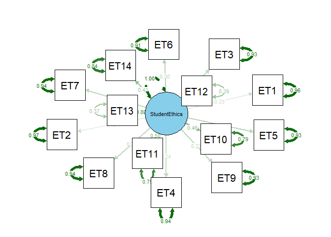

```r
p1 <- plot_sem_model(fit.ethics, "Student Ethics")
```

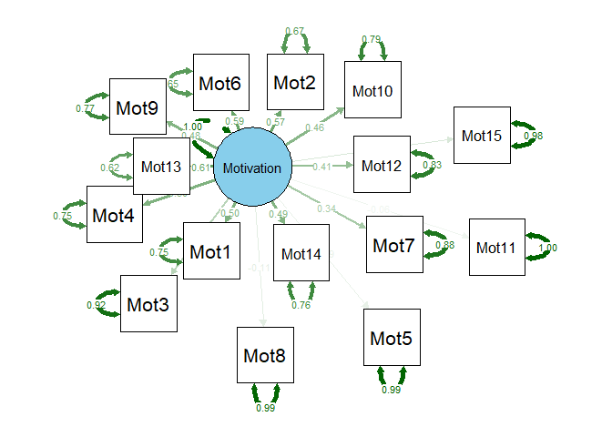

```r
p2 <- plot_sem_model(fit.motivation, "Motivation")
```

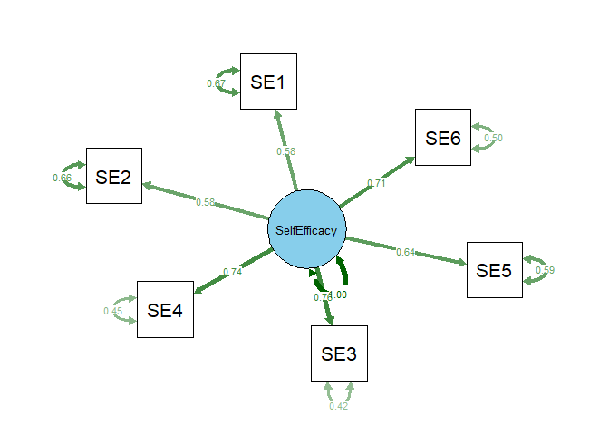

```r
p3 <- plot_sem_model(fit.efficacy, "Self Efficacy")
```

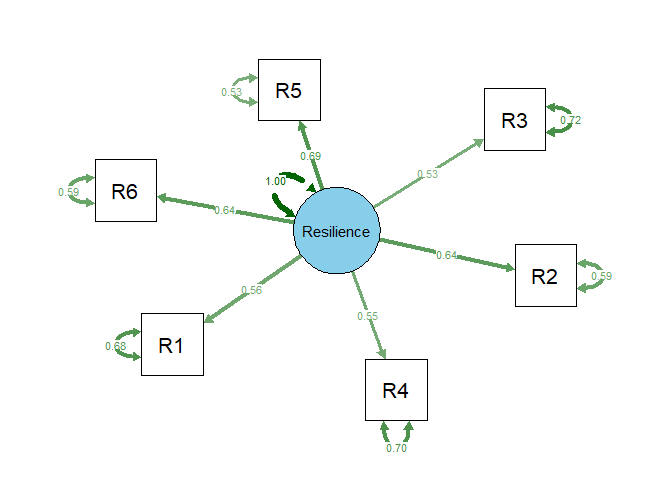

```r
p4 <- plot_sem_model(fit.resilience, "Resilience")
```

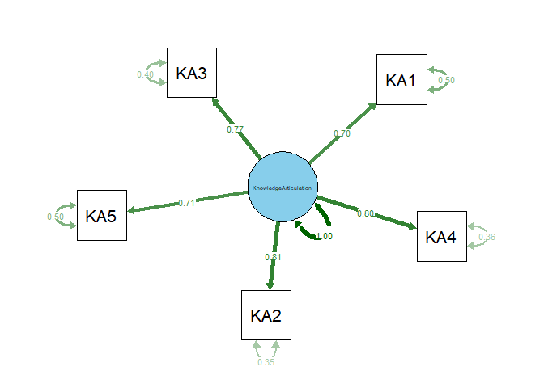

```r
p5 <- plot_sem_model(fit.knowledge, "Knowledge Articulation")
```

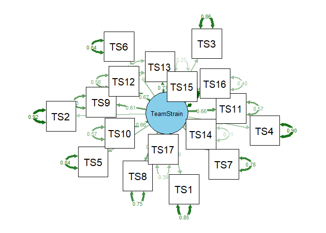

```r
p6 <- plot_sem_model(fit.teamstrain, "Team Strain")
```

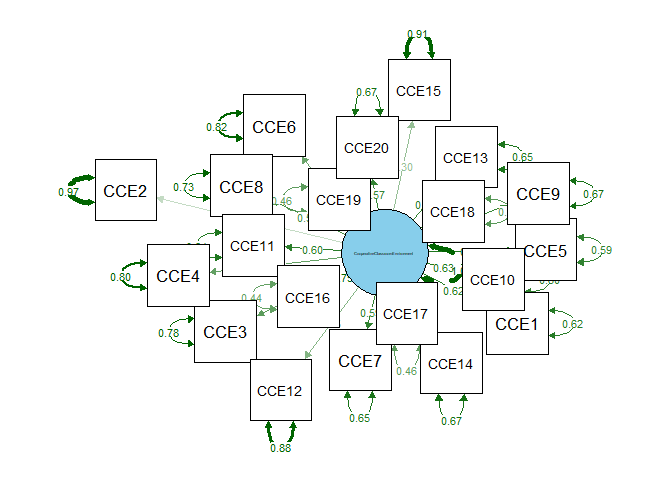

```r
p7 <- plot_sem_model(fit.cce, "Cooperative Classroom Environment")
```

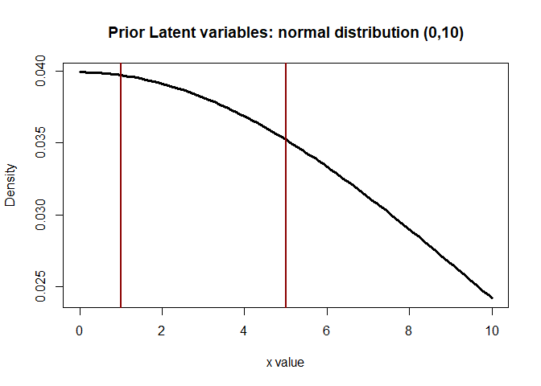

```r
plot(seq(0,10,.1), dnorm(seq(0,10,.1),0,10), type="l", lty=1, lwd = 3, xlab="x value",
     ylab="Density", main="Prior Latent variables: normal distribution (0,10)")
# vertical line
abline(v=1, col="darkred", lwd=2)
abline(v=5, col="darkred", lwd=2)
```

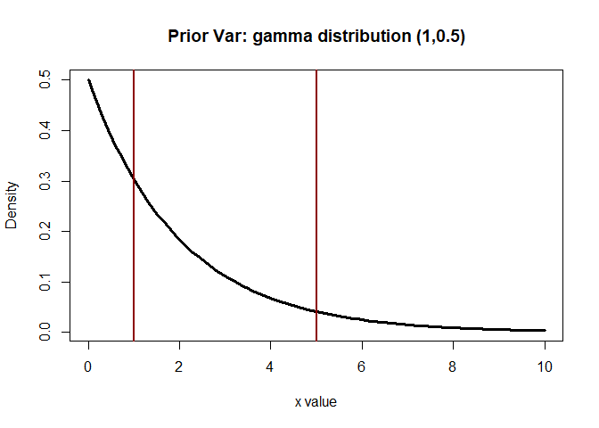

```r
plot(seq(0,10,.1), dgamma(seq(0,10,.1),1,0.5), type="l", lty=1, lwd = 3, xlab="x value",
     ylab="Density", main="Prior Var: gamma distribution (1,0.5)")
# vertical line
abline(v=1, col="darkred", lwd=2)
abline(v=5, col="darkred", lwd=2)
```

#### CFA com as variáveis sugeridos pelo artigo

```r
# individual params
n_chains <- 3 # 5
burn_in <- 1500
sample_estimate <- 3000
```

##### Student Ethics

```r
# Student Ethics
model.ethics_article <- 'StudentEthics =~ ET12 + ET13'
fit.ethics_article <- bcfa(model.ethics_article, data = df, std.lv = TRUE,
                      n.chains = n_chains, burnin=burn_in,
                      sample=sample_estimate, target = "stan")
```

```
## Computing post-estimation metrics (including lvs if requested)...
```

```r
summary(fit.ethics_article, standardized = TRUE, rsquare = TRUE)
```

```
## blavaan 0.5.8 ended normally after 3000 iterations
##
##   Estimator                                      BAYES
##   Optimization method                             MCMC
##   Number of model parameters                         4
##
##   Number of observations                           566
##
##   Statistic                                 MargLogLik         PPP
##   Value                                      -1334.122       0.506
##
## Parameter Estimates:
##
##
## Latent Variables:
##                    Estimate  Post.SD pi.lower pi.upper   Std.lv  Std.all
##   StudentEthics =~
##     ET12              0.812    0.095    0.656    0.969    0.812    0.864
##     ET13              0.803    0.096    0.647    0.961    0.803    0.862
##      Rhat    Prior
##
##     1.009    normal(0,10)
##     1.010    normal(0,10)
##
## Variances:
##                    Estimate  Post.SD pi.lower pi.upper   Std.lv  Std.all
##    .ET12              0.223    0.149    0.001    0.436    0.223    0.253
##    .ET13              0.222    0.146    0.001    0.431    0.222    0.256
##     StudentEthics     1.000                               1.000    1.000
##      Rhat    Prior
##     1.010 gamma(1,.5)[sd]
##     1.011 gamma(1,.5)[sd]
##
##
## R-Square:
##                    Estimate
##     ET12              0.747
##     ET13              0.744
```

```r
fitMeasures(fit.ethics_article)
```

```
##       npar       logl        ppp        bic        dic      p_dic       waic
##      4.000  -1317.439      0.506   2660.226   2638.628      1.875   2641.456
##     p_waic    se_waic      looic      p_loo     se_loo margloglik
##      4.626     64.512   2641.472      4.634     64.517  -1334.122
```

##### Motivation

```r
# Motivation
model.motivation_article <- 'Motivation =~ Mot5 + Mot8 + Mot11'
fit.motivation_article <- bcfa(model.motivation_article, data = df, std.lv = TRUE,
                      n.chains = n_chains, burnin=burn_in,
                      sample=sample_estimate, target = "stan")
```

```
##
##
##
## Computing post-estimation metrics (including lvs if requested)...
```

```r
summary(fit.motivation_article, standardized = TRUE, rsquare = TRUE)
```

```
## blavaan 0.5.8 ended normally after 3000 iterations
##
##   Estimator                                      BAYES
##   Optimization method                             MCMC
##   Number of model parameters                         6
##
##   Number of observations                           566
##
##   Statistic                                 MargLogLik         PPP
##   Value                                      -2126.810       0.495
##
## Parameter Estimates:
##
##
## Latent Variables:
##                    Estimate  Post.SD pi.lower pi.upper   Std.lv  Std.all
##   Motivation =~
##     Mot5              0.555    0.043    0.470    0.639    0.555    0.629
##     Mot8              0.614    0.046    0.525    0.703    0.614    0.670
##     Mot11             0.620    0.046    0.530    0.711    0.620    0.666
##      Rhat    Prior
##
##     1.000    normal(0,10)
##     1.000    normal(0,10)
##     1.000    normal(0,10)
##
## Variances:
##                    Estimate  Post.SD pi.lower pi.upper   Std.lv  Std.all
##    .Mot5              0.472    0.042    0.392    0.556    0.472    0.605
##    .Mot8              0.462    0.047    0.371    0.553    0.462    0.551
##    .Mot11             0.482    0.048    0.388    0.577    0.482    0.556
##     Motivation        1.000                               1.000    1.000
##      Rhat    Prior
##     1.000 gamma(1,.5)[sd]
##     1.000 gamma(1,.5)[sd]
##     1.000 gamma(1,.5)[sd]
##
##
## R-Square:
##                    Estimate
##     Mot5              0.395
##     Mot8              0.449
##     Mot11             0.444
```

```r
fitMeasures(fit.motivation_article)
```

```
##       npar       logl        ppp        bic        dic      p_dic       waic
##      6.000  -2100.663      0.495   4239.346   4213.284      5.980   4214.462
##     p_waic    se_waic      looic      p_loo     se_loo margloglik
##      7.097     68.905   4214.466      7.099     68.905  -2126.810
```

##### Self-Efficacy

```r
# Self-Efficacy
model.efficacy_article <- 'SelfEfficacy =~ SE1 + SE2 + SE3 + SE4 + SE5 + SE6'
fit.efficacy_article <- bcfa(model.efficacy_article, data = df, std.lv = TRUE,
                      n.chains = n_chains, burnin=burn_in,
                      sample=sample_estimate, target = "stan")
```

```
##
##
##
## Computing post-estimation metrics (including lvs if requested)...
```

```r
summary(fit.efficacy_article, standardized = TRUE, rsquare = TRUE)
```

```
## blavaan 0.5.8 ended normally after 3000 iterations
##
##   Estimator                                      BAYES
##   Optimization method                             MCMC
##   Number of model parameters                        12
##
##   Number of observations                           566
##
##   Statistic                                 MargLogLik         PPP
##   Value                                      -3092.317       0.000
##
## Parameter Estimates:
##
##
## Latent Variables:
##                    Estimate  Post.SD pi.lower pi.upper   Std.lv  Std.all
##   SelfEfficacy =~
##     SE1               0.414    0.030    0.357    0.474    0.414    0.578
##     SE2               0.447    0.032    0.384    0.510    0.447    0.584
##     SE3               0.514    0.026    0.462    0.567    0.514    0.762
##     SE4               0.494    0.027    0.445    0.547    0.494    0.741
##     SE5               0.441    0.029    0.385    0.498    0.441    0.638
##     SE6               0.458    0.026    0.407    0.511    0.458    0.705
##      Rhat    Prior
##
##     1.000    normal(0,10)
##     1.000    normal(0,10)
##     1.000    normal(0,10)
##     1.000    normal(0,10)
##     1.000    normal(0,10)
##     1.000    normal(0,10)
##
## Variances:
##                    Estimate  Post.SD pi.lower pi.upper   Std.lv  Std.all
##    .SE1               0.342    0.023    0.300    0.389    0.342    0.666
##    .SE2               0.385    0.026    0.337    0.439    0.385    0.659
##    .SE3               0.191    0.016    0.161    0.224    0.191    0.419
##    .SE4               0.200    0.016    0.172    0.232    0.200    0.451
##    .SE5               0.283    0.020    0.247    0.324    0.283    0.593
##    .SE6               0.212    0.016    0.182    0.245    0.212    0.503
##     SelfEfficacy      1.000                               1.000    1.000
##      Rhat    Prior
##     1.000 gamma(1,.5)[sd]
##     1.000 gamma(1,.5)[sd]
##     1.000 gamma(1,.5)[sd]
##     1.000 gamma(1,.5)[sd]
##     1.000 gamma(1,.5)[sd]
##     1.000 gamma(1,.5)[sd]
##
##
## R-Square:
##                    Estimate
##     SE1               0.334
##     SE2               0.341
##     SE3               0.581
##     SE4               0.549
##     SE5               0.407
##     SE6               0.497
```

```r
fitMeasures(fit.efficacy_article)
```

```
##       npar       logl        ppp        bic        dic      p_dic       waic
##     12.000  -3033.293      0.000   6142.628   6090.675     12.045   6099.259
##     p_waic    se_waic      looic      p_loo     se_loo margloglik
##     20.325    162.053   6099.244     20.318    162.046  -3092.317
```

##### Resilience

```r
# Resilience
model.resilience_article <- 'Resilience =~ R2 + R5 + R6'
fit.resilience_article <- bcfa(model.resilience_article, data = df, std.lv = TRUE,
                      n.chains = n_chains, burnin=burn_in,
                      sample=sample_estimate, target = "stan")
```

```
##
##
##
## Computing post-estimation metrics (including lvs if requested)...
```

```r
summary(fit.resilience_article, standardized = TRUE, rsquare = TRUE)
```

```
## blavaan 0.5.8 ended normally after 3000 iterations
##
##   Estimator                                      BAYES
##   Optimization method                             MCMC
##   Number of model parameters                         6
##
##   Number of observations                           566
##
##   Statistic                                 MargLogLik         PPP
##   Value                                      -1788.946       0.487
##
## Parameter Estimates:
##
##
## Latent Variables:
##                    Estimate  Post.SD pi.lower pi.upper   Std.lv  Std.all
##   Resilience =~
##     R2                0.395    0.035    0.326    0.462    0.395    0.506
##     R5                0.693    0.040    0.616    0.775    0.693    0.869
##     R6                0.555    0.036    0.484    0.625    0.555    0.736
##      Rhat    Prior
##
##     1.000    normal(0,10)
##     1.000    normal(0,10)
##     1.000    normal(0,10)
##
## Variances:
##                    Estimate  Post.SD pi.lower pi.upper   Std.lv  Std.all
##    .R2                0.452    0.030    0.395    0.515    0.452    0.744
##    .R5                0.155    0.043    0.062    0.233    0.155    0.244
##    .R6                0.262    0.031    0.202    0.325    0.262    0.459
##     Resilience        1.000                               1.000    1.000
##      Rhat    Prior
##     1.000 gamma(1,.5)[sd]
##     1.000 gamma(1,.5)[sd]
##     1.000 gamma(1,.5)[sd]
##
##
## R-Square:
##                    Estimate
##     R2                0.256
##     R5                0.756
##     R6                0.541
```

```r
fitMeasures(fit.resilience_article)
```

```
##       npar       logl        ppp        bic        dic      p_dic       waic
##      6.000  -1761.057      0.487   3560.135   3534.266      6.076   3539.688
##     p_waic    se_waic      looic      p_loo     se_loo margloglik
##     11.192     97.906   3539.646     11.171     97.885  -1788.946
```

##### Knowledge Articulation

```r
# Knowledge Articulation
model.knowledge_article <- 'KnowledgeArticulation =~ KA1 + KA2 + KA3 + KA4 + KA5'
fit.knowledge_article <- bcfa(model.knowledge_article, data = df, std.lv = TRUE,
                      n.chains = n_chains, burnin=burn_in,
                      sample=sample_estimate, target = "stan")
```

```
##
##
##
## Computing post-estimation metrics (including lvs if requested)...
```

```r
summary(fit.knowledge_article, standardized = TRUE, rsquare = TRUE)
```

```
## blavaan 0.5.8 ended normally after 3000 iterations
##
##   Estimator                                      BAYES
##   Optimization method                             MCMC
##   Number of model parameters                        10
##
##   Number of observations                           566
##
##   Statistic                                 MargLogLik         PPP
##   Value                                      -2156.758       0.000
##
## Parameter Estimates:
##
##
## Latent Variables:
##                            Estimate  Post.SD pi.lower pi.upper   Std.lv
##   KnowledgeArticulation =~
##     KA1                       0.477    0.026    0.426    0.529    0.477
##     KA2                       0.522    0.024    0.476    0.570    0.522
##     KA3                       0.477    0.023    0.432    0.524    0.477
##     KA4                       0.511    0.024    0.465    0.559    0.511
##     KA5                       0.450    0.025    0.402    0.499    0.450
##   Std.all     Rhat    Prior
##
##     0.704    1.000    normal(0,10)
##     0.807    1.000    normal(0,10)
##     0.774    1.000    normal(0,10)
##     0.802    1.000    normal(0,10)
##     0.709    1.000    normal(0,10)
##
## Variances:
##                    Estimate  Post.SD pi.lower pi.upper   Std.lv  Std.all
##    .KA1               0.231    0.016    0.202    0.264    0.231    0.504
##    .KA2               0.146    0.012    0.124    0.171    0.146    0.349
##    .KA3               0.153    0.012    0.131    0.177    0.153    0.402
##    .KA4               0.145    0.012    0.123    0.170    0.145    0.357
##    .KA5               0.200    0.014    0.173    0.230    0.200    0.498
##     KnowldgArtcltn    1.000                               1.000    1.000
##      Rhat    Prior
##     1.000 gamma(1,.5)[sd]
##     1.000 gamma(1,.5)[sd]
##     1.000 gamma(1,.5)[sd]
##     1.000 gamma(1,.5)[sd]
##     1.000 gamma(1,.5)[sd]
##
##
## R-Square:
##                    Estimate
##     KA1               0.496
##     KA2               0.651
##     KA3               0.598
##     KA4               0.643
##     KA5               0.502
```

```r
fitMeasures(fit.knowledge_article)
```

```
##       npar       logl        ppp        bic        dic      p_dic       waic
##     10.000  -2105.026      0.000   4273.420   4229.966      9.957   4252.401
##     p_waic    se_waic      looic      p_loo     se_loo margloglik
##     31.324    195.531   4252.429     31.338    195.532  -2156.758
```

##### Team Strain

```r
# Team Strain
model.teamstrain_article <- 'TeamStrain =~ TS10 + TS11 + TS12 + TS13 +
                                   TS14 + TS15 + TS16 + TS17'
fit.teamstrain_article <- bcfa(model.teamstrain_article, data = df, std.lv = TRUE,
                      n.chains = n_chains, burnin=burn_in,
                      sample=sample_estimate, target = "stan")
```

```
##
##
##
## Computing post-estimation metrics (including lvs if requested)...
```

```r
summary(fit.teamstrain_article, standardized = TRUE, rsquare = TRUE)
```

```
## blavaan 0.5.8 ended normally after 3000 iterations
##
##   Estimator                                      BAYES
##   Optimization method                             MCMC
##   Number of model parameters                        16
##
##   Number of observations                           566
##
##   Statistic                                 MargLogLik         PPP
##   Value                                      -3250.269       0.000
##
## Parameter Estimates:
##
##
## Latent Variables:
##                    Estimate  Post.SD pi.lower pi.upper   Std.lv  Std.all
##   TeamStrain =~
##     TS10              0.481    0.028    0.427    0.537    0.481    0.656
##     TS11              0.486    0.028    0.431    0.542    0.486    0.655
##     TS12              0.504    0.029    0.447    0.562    0.504    0.671
##     TS13              0.510    0.023    0.466    0.557    0.510    0.793
##     TS14              0.520    0.020    0.480    0.561    0.520    0.860
##     TS15              0.556    0.021    0.516    0.598    0.556    0.885
##     TS16              0.446    0.022    0.404    0.490    0.446    0.762
##     TS17              0.436    0.021    0.397    0.478    0.436    0.759
##      Rhat    Prior
##
##     1.000    normal(0,10)
##     1.000    normal(0,10)
##     1.000    normal(0,10)
##     1.000    normal(0,10)
##     1.000    normal(0,10)
##     1.000    normal(0,10)
##     1.000    normal(0,10)
##     1.000    normal(0,10)
##
## Variances:
##                    Estimate  Post.SD pi.lower pi.upper   Std.lv  Std.all
##    .TS10              0.307    0.020    0.271    0.348    0.307    0.570
##    .TS11              0.314    0.020    0.276    0.356    0.314    0.571
```

[output cut: 13 more lines]

```
##     1.000 gamma(1,.5)[sd]
##     1.000 gamma(1,.5)[sd]
##     1.000 gamma(1,.5)[sd]
##
##
## R-Square:
##                    Estimate
##     TS10              0.430
##     TS11              0.429
##     TS12              0.450
##     TS13              0.628
##     TS14              0.739
##     TS15              0.782
##     TS16              0.581
##     TS17              0.576
```

```r
fitMeasures(fit.teamstrain_article)
```

```
##       npar       logl        ppp        bic        dic      p_dic       waic
##     16.000  -3166.250      0.000   6433.890   6364.082     15.791   6396.123
##     p_waic    se_waic      looic      p_loo     se_loo margloglik
##     46.259    301.440   6395.766     46.080    301.275  -3250.269
```

##### Cooperative Classroom Environment

```r
# Cooperative Classroom Environment
model.cce_article <- 'CooperativeClassroomEnvironment =~ CCE1 + CCE3 + CCE4 +
                                  CCE5 + CCE8 + CCE9 + CCE10 + CCE11'
fit.cce_article <- bcfa(model.cce_article, data = df, std.lv = TRUE,
                      n.chains = n_chains, burnin=burn_in,
                      sample=sample_estimate, target = "stan")
```

```
##
##
##
## Computing post-estimation metrics (including lvs if requested)...
```

```r
summary(fit.cce_article, standardized = TRUE, rsquare = TRUE)
```

```
## blavaan 0.5.8 ended normally after 3000 iterations
##
##   Estimator                                      BAYES
##   Optimization method                             MCMC
##   Number of model parameters                        16
##
##   Number of observations                           566
##
##   Statistic                                 MargLogLik         PPP
##   Value                                      -4217.866       0.000
##
## Parameter Estimates:
##
##
## Latent Variables:
##                                      Estimate  Post.SD pi.lower pi.upper
##   CooperativeClassroomEnvironment =~
##     CCE1                                0.488    0.031    0.429    0.549
##     CCE3                                0.421    0.032    0.359    0.486
##     CCE4                                0.406    0.031    0.347    0.469
##     CCE5                                0.435    0.026    0.386    0.486
##     CCE8                                0.422    0.031    0.361    0.483
##     CCE9                                0.506    0.029    0.451    0.562
##     CCE10                               0.482    0.026    0.433    0.535
##     CCE11                               0.499    0.027    0.447    0.552
##    Std.lv  Std.all     Rhat    Prior
##
##     0.488    0.653    1.000    normal(0,10)
##     0.421    0.550    1.000    normal(0,10)
##     0.406    0.563    1.000    normal(0,10)
##     0.435    0.673    1.000    normal(0,10)
##     0.422    0.570    1.000    normal(0,10)
##     0.506    0.703    1.000    normal(0,10)
##     0.482    0.733    1.000    normal(0,10)
##     0.499    0.727    1.000    normal(0,10)
##
## Variances:
##                    Estimate  Post.SD pi.lower pi.upper   Std.lv  Std.all
##    .CCE1              0.321    0.023    0.278    0.368    0.321    0.574
##    .CCE3              0.410    0.027    0.359    0.466    0.410    0.698
```

[output cut: 13 more lines]

```
##     1.000 gamma(1,.5)[sd]
##     1.000 gamma(1,.5)[sd]
##     1.000 gamma(1,.5)[sd]
##
##
## R-Square:
##                    Estimate
##     CCE1              0.426
##     CCE3              0.302
##     CCE4              0.317
##     CCE5              0.453
##     CCE8              0.324
##     CCE9              0.494
##     CCE10             0.537
##     CCE11             0.528
```

```r
fitMeasures(fit.cce_article)
```

```
##       npar       logl        ppp        bic        dic      p_dic       waic
##     16.000  -4139.713      0.000   8380.815   8311.440     16.007   8329.217
##     p_waic    se_waic      looic      p_loo     se_loo margloglik
##     33.232    208.507   8329.298     33.273    208.520  -4217.866
```

##### Gráficos

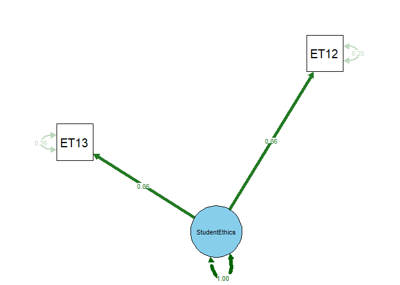

```r
p1 <- plot_sem_model(fit.ethics_article, "Student Ethics")
```

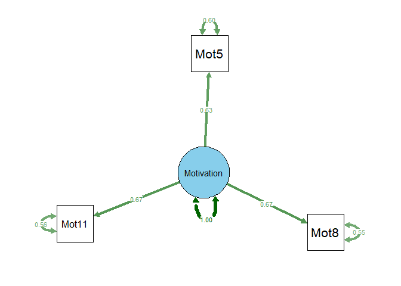

```r
p2 <- plot_sem_model(fit.motivation_article, "Motivation")
```

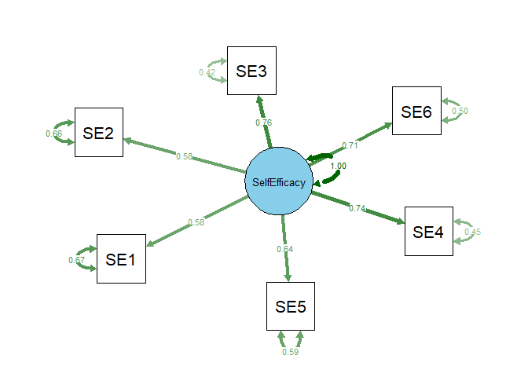

```r
p3 <- plot_sem_model(fit.efficacy_article, "Self Efficacy")
```

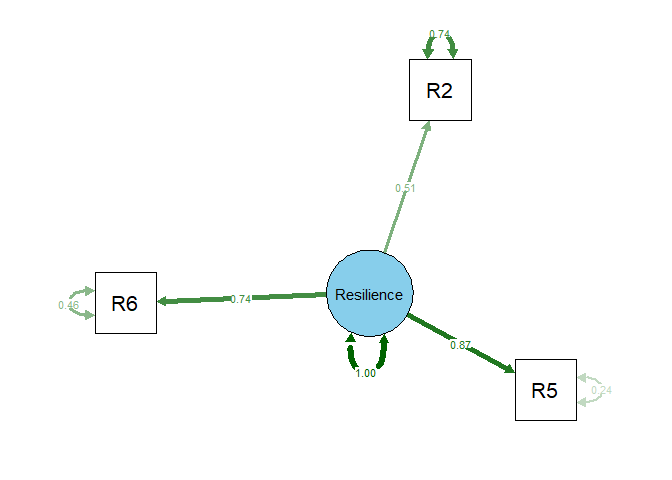

```r
p4 <- plot_sem_model(fit.resilience_article, "Resilience")
```

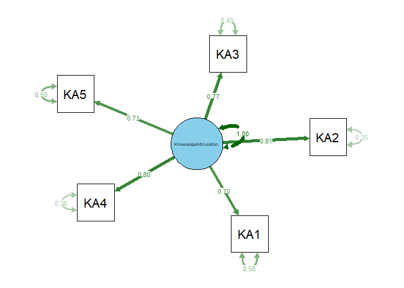

```r
p5 <- plot_sem_model(fit.knowledge_article, "Knowledge Articulation")
```

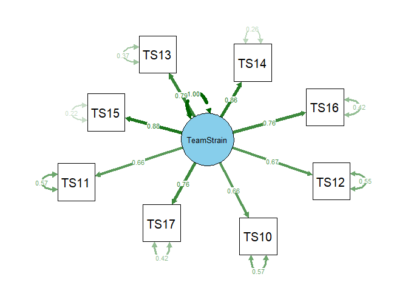

```r
p6 <- plot_sem_model(fit.teamstrain_article, "Team Strain")
```

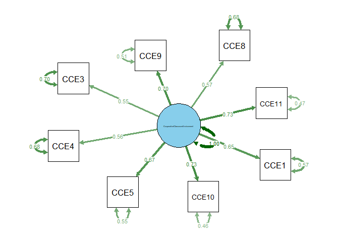

```r
p7 <- plot_sem_model(fit.cce_article, "Cooperative Classroom Environment")
```

### 2 - CFA Global

Vai ter em conta as covariâncias entre os fatores e ver as variâncias.

```r
# individual params
n_chains <- 3 # 5
burn_in <- 500
sample_estimate <- 1500
```

#### Com as variáveis que os autores escolheram

```r
modelcfa.authors <- '
  StudentEthics =~ ET12 + ET13
  Motivation =~ Mot5 + Mot8 + Mot11
  SelfEfficacy =~ SE1 + SE2 + SE3 + SE4 + SE5 + SE6
  Resilience =~ R2 + R5 + R6
  KnowledgeArticulation =~ KA1 + KA2 + KA3 + KA4 + KA5
  TeamStrain =~ TS10 + TS11 + TS12 + TS13 + TS14 + TS15 + TS16 + TS17
  CooperativeClassroomEnvironment =~ CCE1 + CCE3 + CCE4 + CCE5 + CCE8 + CCE9 + CCE10 + CCE11

   # variances
  ET12 ~~ ET12
  ET13 ~~ ET13
  Mot5 ~~ Mot5
  Mot8 ~~ Mot8
  Mot11 ~~ Mot11
  SE1 ~~ SE1
  SE2 ~~ SE2
  SE3 ~~ SE3
  SE4 ~~ SE4
  SE5 ~~ SE5
  SE6 ~~ SE6
  R2 ~~ R2
  R5 ~~ R5
  R6 ~~ R6
  KA1 ~~ KA1
  KA2 ~~ KA2
  KA3 ~~ KA3
  KA4 ~~ KA4
  KA5 ~~ KA5
  TS10 ~~ TS10
  TS11 ~~ TS11
  TS12 ~~ TS12
  TS13 ~~ TS13
  TS14 ~~ TS14
  TS15 ~~ TS15
  TS16 ~~ TS16
  TS17 ~~ TS17
  CCE1 ~~ CCE1
  CCE3 ~~ CCE3
  CCE4 ~~ CCE4
  CCE5 ~~ CCE5
  CCE8 ~~ CCE8
  CCE9 ~~ CCE9
  CCE10 ~~ CCE10
  CCE11 ~~ CCE11
'
fitcfa.authors <- bcfa(modelcfa.authors, data = df, std.lv = TRUE,
                      n.chains = n_chains, burnin=burn_in,
                      sample=sample_estimate, target = "stan")
```

```
## Computing post-estimation metrics (including lvs if requested)...
```

```r
summary(fitcfa.authors, standardized = TRUE, rsquare = TRUE)
```

```
## blavaan 0.5.8 ended normally after 1500 iterations
##
##   Estimator                                      BAYES
##   Optimization method                             MCMC
##   Number of model parameters                        91
##
##   Number of observations                           566
##
##   Statistic                                 MargLogLik         PPP
##   Value                                     -17777.438       0.000
##
## Parameter Estimates:
##
##
## Latent Variables:
##                                      Estimate  Post.SD pi.lower pi.upper
##   StudentEthics =~
##     ET12                                0.917    0.043    0.814    0.990
##     ET13                                0.710    0.041    0.634    0.802
##   Motivation =~
##     Mot5                                0.595    0.044    0.511    0.683
##     Mot8                                0.604    0.045    0.516    0.694
##     Mot11                               0.592    0.045    0.504    0.678
##   SelfEfficacy =~
##     SE1                                 0.425    0.030    0.368    0.483
##     SE2                                 0.442    0.031    0.384    0.504
##     SE3                                 0.518    0.026    0.467    0.570
##     SE4                                 0.487    0.026    0.436    0.538
##     SE5                                 0.439    0.029    0.382    0.495
##     SE6                                 0.463    0.026    0.412    0.514
##   Resilience =~
##     R2                                  0.406    0.035    0.339    0.478
##     R5                                  0.679    0.035    0.608    0.748
##     R6                                  0.569    0.034    0.501    0.635
##   KnowledgeArticulation =~
##     KA1                                 0.476    0.026    0.425    0.528
##     KA2                                 0.527    0.023    0.483    0.576
##     KA3                                 0.479    0.023    0.434    0.527
##     KA4                                 0.513    0.024    0.469    0.560
##     KA5                                 0.447    0.025    0.400    0.497
```

[output cut: 230 more lines]

```
##     TS11              0.434
##     TS12              0.448
##     TS13              0.621
##     TS14              0.738
##     TS15              0.781
##     TS16              0.593
##     TS17              0.589
##     CCE1              0.430
##     CCE3              0.297
##     CCE4              0.313
##     CCE5              0.468
##     CCE8              0.325
##     CCE9              0.495
##     CCE10             0.536
##     CCE11             0.522
```

```r
fitMeasures(fitcfa.authors)
```

```
##       npar       logl        ppp        bic        dic      p_dic       waic
##     91.000 -17383.463      0.000  35343.576  34945.449     89.262  35063.360
##     p_waic    se_waic      looic      p_loo     se_loo margloglik
##    200.183    707.466  35059.401    198.203    705.778 -17777.438
```

```r
semPaths(fitcfa.authors,
         what = "std",
         layout = "tree",
         edge.label.cex = 1.0,
         sizeMan = 6,
         sizeLat = 8,
         nCharNodes = 6,
         residuals = TRUE,
         intercepts = FALSE,
         optimizeLatRes = TRUE,
         edge.color = "black",
         color = list(lat = "darkgreen", man = "white"),
         mar = c(6, 6, 6, 6)
)
```

[figure not shown]

#### (X) Com todas as variáveis

```r
if(FALSE){
modelcfa.global <- '
  StudentEthics =~ ET1 + ET2 + ET3 + ET4 + ET5 + ET6 + ET7 + ET8 + ET9 + ET10 + ET11 + ET12 + ET13
  Motivation =~ Mot1 + Mot2 + Mot3 + Mot4 + Mot5 + Mot6 + Mot7 + Mot8 + Mot9 + Mot10 + Mot11 + Mot12 + Mot13 + Mot14 + Mot15
  SelfEfficacy =~ SE1 + SE2 + SE3 + SE4 + SE5 + SE6
  Resilience =~ R1 + R2 + R3 + R4 + R5 + R6
  KnowledgeArticulation =~ KA1 + KA2 + KA3 + KA4 + KA5
  TeamStrain =~ TS1 + TS2 + TS3 + TS4 + TS5 + TS6 + TS7 + TS8 + TS9 + TS10 + TS11 + TS12 + TS13 + TS14 + TS15 + TS16 + TS17
  CooperativeClassroomEnvironment =~ CCE1 + CCE2 + CCE3 + CCE4 + CCE5 + CCE6 + CCE7 + CCE8 + CCE9 + CCE10 + CCE11
'
fitcfa.global <- bcfa(modelcfa.global, data = df, std.lv = TRUE,
                      n.chains = n_chains, burnin=burn_in,
                      sample=sample_estimate, target = "stan")
summary(fitcfa.global, standardized = TRUE, rsquare = TRUE)
fitMeasures(fitcfa.global)

semPaths(fitcfa.global,
         what = "std",
         layout = "tree",
         edge.label.cex = 1.0,
         sizeMan = 6,
         sizeLat = 8,
         nCharNodes = 6,
         residuals = TRUE,
         intercepts = FALSE,
         optimizeLatRes = TRUE,
         edge.color = "black",
         color = list(lat = "darkgreen", man = "white"),
         mar = c(6, 6, 6, 6)
)
}
```

### 3 - SEM

#### Estimação com FA criadas por nós

```r
# individual params
n_chains <- 5 # 5
burn_in <- 500
sample_estimate <- 1500
```

```r
model.sem <- '
  # measurement model
  StudentEthics =~ ET12 + ET13
  Motivation =~ Mot5 + Mot8 + Mot11
  SelfEfficacy =~ SE1 + SE2 + SE3 + SE4 + SE5 + SE6
  Resilience =~ R2 + R5 + R6
  KnowledgeArticulation =~ KA1 + KA2 + KA3 + KA4 + KA5
  TeamStrain =~ TS10 + TS11 + TS12 + TS13 + TS14 + TS15 + TS16 + TS17
  CooperativeClassroomEnvironment =~ CCE1 + CCE3 + CCE4 + CCE5 + CCE8 + CCE9 + CCE10 + CCE11

  # regressions
  Motivation ~ Resilience + KnowledgeArticulation + TeamStrain + CooperativeClassroomEnvironment
  SelfEfficacy ~ Resilience + KnowledgeArticulation + TeamStrain + CooperativeClassroomEnvironment
  StudentEthics ~ Motivation + SelfEfficacy

'

model.sem <- bcfa(model.sem, data=df, std.lv=TRUE, n.chains = n_chains,
                 burnin=burn_in, sample=sample_estimate, target = "stan")
```

```
## Computing post-estimation metrics (including lvs if requested)...
```

```r
summary(model.sem, standardized=TRUE, rsquare=TRUE)
```

```
## blavaan 0.5.8 ended normally after 1500 iterations
##
##   Estimator                                      BAYES
##   Optimization method                             MCMC
##   Number of model parameters                        86
##
##   Number of observations                           566
##
##   Statistic                                 MargLogLik         PPP
##   Value                                     -17810.359       0.000
##
## Parameter Estimates:
##
##
## Latent Variables:
##                                      Estimate  Post.SD pi.lower pi.upper
##   StudentEthics =~
##     ET12                                0.877    0.050    0.766    0.957
##     ET13                                0.695    0.048    0.614    0.801
##   Motivation =~
##     Mot5                                0.556    0.041    0.478    0.637
##     Mot8                                0.583    0.044    0.496    0.670
##     Mot11                               0.570    0.044    0.485    0.657
##   SelfEfficacy =~
##     SE1                                 0.353    0.025    0.305    0.403
##     SE2                                 0.368    0.027    0.316    0.423
##     SE3                                 0.428    0.023    0.385    0.474
##     SE4                                 0.406    0.024    0.361    0.454
##     SE5                                 0.365    0.024    0.316    0.412
##     SE6                                 0.386    0.022    0.343    0.428
##   Resilience =~
##     R2                                  0.407    0.034    0.341    0.474
##     R5                                  0.683    0.036    0.613    0.756
##     R6                                  0.567    0.034    0.501    0.635
##   KnowledgeArticulation =~
##     KA1                                 0.477    0.027    0.425    0.530
##     KA2                                 0.529    0.024    0.481    0.577
##     KA3                                 0.482    0.024    0.436    0.529
##     KA4                                 0.513    0.024    0.468    0.562
##     KA5                                 0.447    0.024    0.399    0.496
```

[output cut: 227 more lines]

```
##     TS14              0.739
##     TS15              0.783
##     TS16              0.595
##     TS17              0.591
##     CCE1              0.433
##     CCE3              0.299
##     CCE4              0.314
##     CCE5              0.474
##     CCE8              0.328
##     CCE9              0.498
##     CCE10             0.535
##     CCE11             0.523
##     StudentEthics     0.058
##     Motivation        0.076
##     SelfEfficacy      0.310
```

```r
semPaths(model.sem,
         what = "std",
         layout = "tree",
         edge.label.cex = 1.0,
         sizeMan = 6,
         sizeLat = 8,
         nCharNodes = 6,
         residuals = TRUE,
         intercepts = FALSE,
         optimizeLatRes = TRUE,
         edge.color = "black",
         color = list(lat = "darkgreen", man = "white"),
         mar = c(6, 6, 6, 6)
)
```

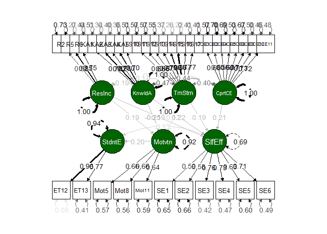

#### Estimação com construtos dos autores

```r
# ler csv
df_FAauth <- read_csv("../data/4_conjuntos(dev)/construtos_autores.csv")
df_FAauth
```

| ethics | Motivation | Resilience | SelfEfficacy | TeamStrain | KnowledgeArticulation | CoopClass |
| --- | --- | --- | --- | --- | --- | --- |
| 3.5 | 2.000000 | 4.000000 | 3.666667 | 3.125 | 3.6 | 3.750 |
| 5.0 | 3.000000 | 4.333333 | 4.000000 | 3.625 | 4.2 | 4.000 |
| 1.0 | 1.333333 | 5.000000 | 5.000000 | 4.000 | 4.2 | 4.125 |
| 2.0 | 3.000000 | 3.000000 | 3.000000 | 3.000 | 3.0 | 3.000 |
| 4.0 | 2.333333 | 4.000000 | 3.666667 | 3.625 | 2.8 | 3.875 |
| 3.5 | 2.333333 | 4.000000 | 3.833333 | 4.000 | 3.4 | 3.875 |
| 5.0 | 3.000000 | 4.333333 | 4.000000 | 3.625 | 4.2 | 4.000 |
| 3.5 | 4.000000 | 5.000000 | 4.000000 | 4.000 | 3.8 | 3.625 |
| 3.0 | 2.666667 | 2.666667 | 3.166667 | 3.000 | 4.0 | 3.625 |
| 4.0 | 3.333333 | 5.000000 | 3.666667 | 4.000 | 4.0 | 4.500 |

[output cut: 556 more lines]

| ethics <dbl> | Motivation <dbl> | Resilience <dbl> | SelfEfficacy <dbl> | TeamStrain <dbl> | KnowledgeArticulation <dbl> | CoopClass <dbl> |
| --- | --- | --- | --- | --- | --- | --- |
| 3.5 | 2.000000 | 4.000000 | 3.666667 | 3.125 | 3.6 | 3.750 |
| 5.0 | 3.000000 | 4.333333 | 4.000000 | 3.625 | 4.2 | 4.000 |
| 1.0 | 1.333333 | 5.000000 | 5.000000 | 4.000 | 4.2 | 4.125 |
| 2.0 | 3.000000 | 3.000000 | 3.000000 | 3.000 | 3.0 | 3.000 |
| 4.0 | 2.333333 | 4.000000 | 3.666667 | 3.625 | 2.8 | 3.875 |
| 3.5 | 2.333333 | 4.000000 | 3.833333 | 4.000 | 3.4 | 3.875 |
| 5.0 | 3.000000 | 4.333333 | 4.000000 | 3.625 | 4.2 | 4.000 |
| 3.5 | 4.000000 | 5.000000 | 4.000000 | 4.000 | 3.8 | 3.625 |
| 3.0 | 2.666667 | 2.666667 | 3.166667 | 3.000 | 4.0 | 3.625 |
| 4.0 | 3.333333 | 5.000000 | 3.666667 | 4.000 | 4.0 | 4.500 |

```r
model.sem_FAauthors <- '
  # regressions
  Motivation ~ Resilience + KnowledgeArticulation + TeamStrain + CoopClass
  SelfEfficacy ~ Resilience + KnowledgeArticulation + TeamStrain + CoopClass
  ethics ~ Motivation + SelfEfficacy
'

model.sem_FAauthors <- bcfa(model.sem_FAauthors, data=df_FAauth, std.lv=TRUE, n.chains = n_chains,
                 burnin=burn_in, sample=sample_estimate, target = "stan")
```

```
##
##
##
##
##
## Computing post-estimation metrics (including lvs if requested)...
```

```r
summary(model.sem_FAauthors, standardized=TRUE, rsquare=TRUE)
```

```
## blavaan 0.5.8 ended normally after 1500 iterations
##
##   Estimator                                      BAYES
##   Optimization method                             MCMC
##   Number of model parameters                        13
##
##   Number of observations                           566
##
##   Statistic                                 MargLogLik         PPP
##   Value                                      -1721.184       0.004
##
## Parameter Estimates:
##
##
## Regressions:
##                    Estimate  Post.SD pi.lower pi.upper   Std.lv  Std.all
##   Motivation ~
##     Resilience        0.171    0.049    0.076    0.266    0.171    0.150
##     KnowldgArtcltn   -0.248    0.065   -0.377   -0.121   -0.248   -0.179
##     TeamStrain        0.110    0.064   -0.015    0.231    0.110    0.079
##     CoopClass        -0.014    0.065   -0.140    0.114   -0.014   -0.009
##   SelfEfficacy ~
##     Resilience        0.133    0.031    0.072    0.195    0.133    0.165
##     KnowldgArtcltn    0.192    0.041    0.111    0.270    0.192    0.196
##     TeamStrain        0.158    0.040    0.077    0.239    0.158    0.161
##     CoopClass         0.203    0.042    0.120    0.284    0.203    0.198
##   ethics ~
##     Motivation        0.165    0.052    0.061    0.269    0.165    0.135
##     SelfEfficacy      0.196    0.073    0.054    0.339    0.196    0.113
##      Rhat    Prior
##
##     1.000    normal(0,10)
##     1.000    normal(0,10)
##     0.999    normal(0,10)
##     1.000    normal(0,10)
##
##     1.000    normal(0,10)
##     1.000    normal(0,10)
##     1.000    normal(0,10)
##     1.000    normal(0,10)
##
##     1.000    normal(0,10)
##     1.000    normal(0,10)
##
## Variances:
##                    Estimate  Post.SD pi.lower pi.upper   Std.lv  Std.all
##    .Motivation        0.494    0.030    0.439    0.555    0.494    0.957
##    .SelfEfficacy      0.197    0.012    0.175    0.221    0.197    0.765
##    .ethics            0.744    0.045    0.662    0.838    0.744    0.969
##      Rhat    Prior
##     1.000 gamma(1,.5)[sd]
##     1.000 gamma(1,.5)[sd]
##     1.000 gamma(1,.5)[sd]
##
## R-Square:
##                    Estimate
##     Motivation        0.043
##     SelfEfficacy      0.235
##     ethics            0.031
```

```r
semPaths(model.sem_FAauthors,
         what = "std",
         layout = "tree",
         edge.label.cex = 1.0,
         sizeMan = 6,
         sizeLat = 8,
         nCharNodes = 6,
         residuals = TRUE,
         intercepts = FALSE,
         optimizeLatRes = TRUE,
         edge.color = "black",
         color = list(lat = "darkgreen", man = "lightblue"),
         mar = c(6, 6, 6, 6)
)
```

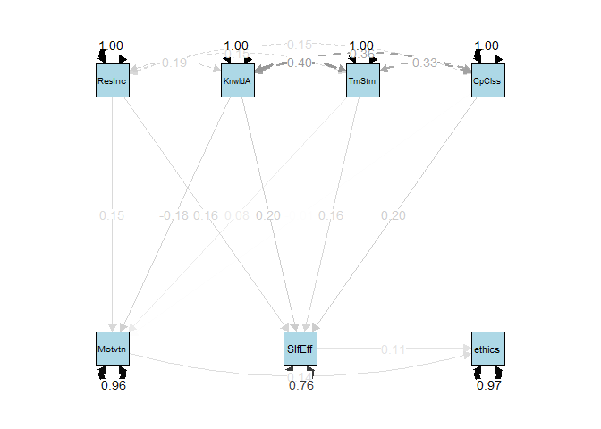